# Exploratory Analysis of Model Outputs

Yimeng Yin

July 06, 2015

# Variables to Examine

- **FR:** Funded ratio
- **ERC_PR:** Employer contribution rate
- **C_PR:** Total contribution rate
- **NC_PR:** Normal cost rate

# Scenario 1

Rxx Single cell 20 - 60, No new entrants, deteriministic return, starting off fully funded.

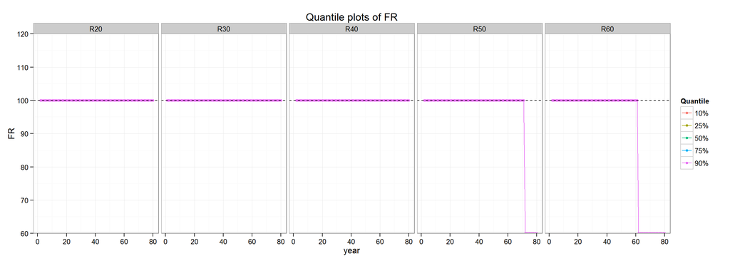

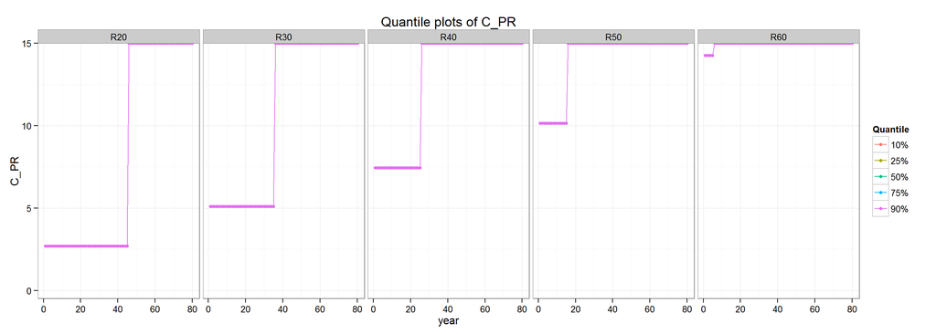

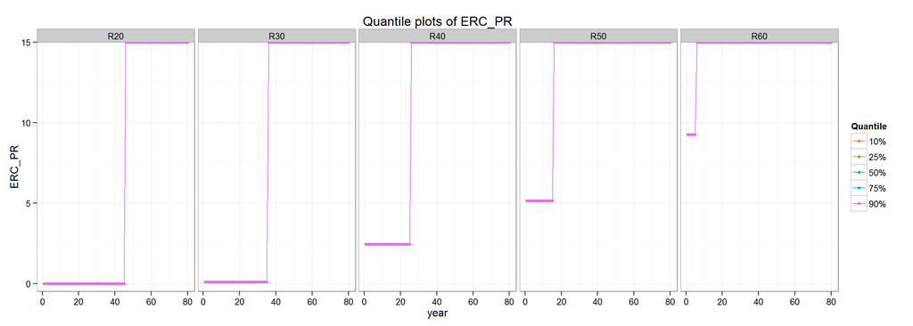

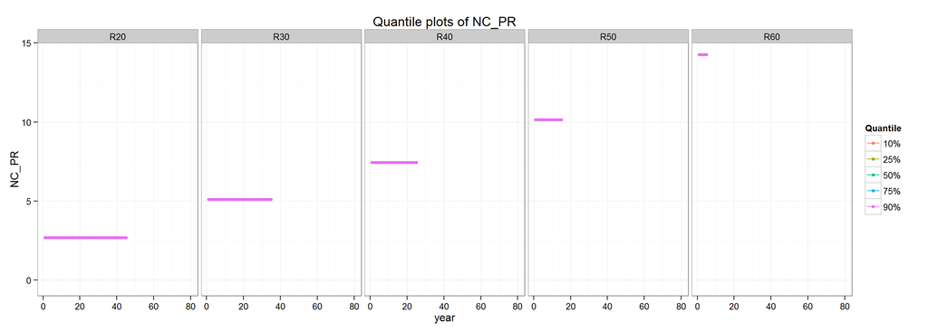

Table for Entry Age 20

| year | AL | MA | AA | FR | UAAL | NC | SC | ADC | EEC | ERC | C | ADC_PR | C_PR | ERC_PR | PR | B | i.r |
| --- | --- | --- | --- | --- | --- | --- | --- | --- | --- | --- | --- | --- | --- | --- | --- | --- | --- |
| 1 | 0.00 | 0.00 | 0.00 | NaN | 0 | 334.36 | 0 | 334.36 | 334.36 | 0 | 334.36 | 2.69 | 2.69 | 0 | 12409.00 | 0.00 | 0.08 |
| 2 | 359.44 | 359.44 | 359.44 | 100 | 0 | 284.91 | 0 | 284.91 | 284.91 | 0 | 284.91 | 2.69 | 2.69 | 0 | 10573.71 | 0.00 | 0.08 |
| 3 | 692.67 | 692.67 | 692.67 | 100 | 0 | 252.39 | 0 | 252.39 | 252.39 | 0 | 252.39 | 2.69 | 2.69 | 0 | 9366.83 | 0.00 | 0.08 |
| 4 | 1015.94 | 1015.94 | 1015.94 | 100 | 0 | 228.21 | 0 | 228.21 | 228.21 | 0 | 228.21 | 2.69 | 2.69 | 0 | 8469.48 | 0.00 | 0.08 |
| 5 | 1337.46 | 1337.46 | 1337.46 | 100 | 0 | 211.22 | 0 | 211.22 | 211.22 | 0 | 211.22 | 2.69 | 2.69 | 0 | 7838.85 | 0.00 | 0.08 |
| 6 | 1664.83 | 1664.83 | 1664.83 | 100 | 0 | 197.95 | 0 | 197.95 | 197.95 | 0 | 197.95 | 2.69 | 2.69 | 0 | 7346.45 | 0.00 | 0.08 |
| 7 | 2002.48 | 2002.48 | 2002.48 | 100 | 0 | 186.88 | 0 | 186.88 | 186.88 | 0 | 186.88 | 2.69 | 2.69 | 0 | 6935.60 | 0.00 | 0.08 |
| 8 | 2353.56 | 2353.56 | 2353.56 | 100 | 0 | 178.03 | 0 | 178.03 | 178.03 | 0 | 178.03 | 2.69 | 2.69 | 0 | 6607.04 | 0.00 | 0.08 |
| 9 | 2721.46 | 2721.46 | 2721.46 | 100 | 0 | 170.96 | 0 | 170.96 | 170.96 | 0 | 170.96 | 2.69 | 2.69 | 0 | 6344.78 | 0.00 | 0.08 |
| 10 | 3109.35 | 3109.35 | 3109.35 | 100 | 0 | 166.39 | 0 | 166.39 | 166.39 | 0 | 166.39 | 2.69 | 2.69 | 0 | 6175.03 | 0.00 | 0.08 |
| 11 | 3521.42 | 3521.42 | 3521.42 | 100 | 0 | 162.26 | 0 | 162.26 | 162.26 | 0 | 162.26 | 2.69 | 2.69 | 0 | 6022.06 | 0.00 | 0.08 |
| 12 | 3959.96 | 3959.96 | 3959.96 | 100 | 0 | 158.80 | 0 | 158.80 | 158.80 | 0 | 158.80 | 2.69 | 2.69 | 0 | 5893.38 | 0.00 | 0.08 |
| 13 | 4427.66 | 4427.66 | 4427.66 | 100 | 0 | 156.09 | 0 | 156.09 | 156.09 | 0 | 156.09 | 2.69 | 2.69 | 0 | 5793.03 | 0.00 | 0.08 |
| 14 | 4927.53 | 4927.53 | 4927.53 | 100 | 0 | 154.13 | 0 | 154.13 | 154.13 | 0 | 154.13 | 2.69 | 2.69 | 0 | 5720.07 | 0.00 | 0.08 |
| 15 | 5462.78 | 5462.78 | 5462.78 | 100 | 0 | 153.04 | 0 | 153.04 | 153.04 | 0 | 153.04 | 2.69 | 2.69 | 0 | 5679.91 | 0.00 | 0.08 |
| 16 | 6037.02 | 6037.02 | 6037.02 | 100 | 0 | 152.44 | 0 | 152.44 | 152.44 | 0 | 152.44 | 2.69 | 2.69 | 0 | 5657.64 | 0.00 | 0.08 |
| 17 | 6653.67 | 6653.67 | 6653.67 | 100 | 0 | 152.26 | 0 | 152.26 | 152.26 | 0 | 152.26 | 2.69 | 2.69 | 0 | 5650.69 | 0.00 | 0.08 |
| 18 | 7316.37 | 7316.37 | 7316.37 | 100 | 0 | 152.41 | 0 | 152.41 | 152.41 | 0 | 152.41 | 2.69 | 2.69 | 0 | 5656.40 | 0.00 | 0.08 |
| 19 | 8028.94 | 8028.94 | 8028.94 | 100 | 0 | 152.67 | 0 | 152.67 | 152.67 | 0 | 152.67 | 2.69 | 2.69 | 0 | 5666.04 | 0.00 | 0.08 |
| 20 | 8795.23 | 8795.23 | 8795.23 | 100 | 0 | 153.22 | 0 | 153.22 | 153.22 | 0 | 153.22 | 2.69 | 2.69 | 0 | 5686.33 | 0.00 | 0.08 |
| 21 | 9619.58 | 9619.58 | 9619.58 | 100 | 0 | 154.06 | 0 | 154.06 | 154.06 | 0 | 154.06 | 2.69 | 2.69 | 0 | 5717.66 | 0.00 | 0.08 |
| 22 | 10506.67 | 10506.67 | 10506.67 | 100 | 0 | 155.24 | 0 | 155.24 | 155.24 | 0 | 155.24 | 2.69 | 2.69 | 0 | 5761.39 | 0.00 | 0.08 |
| 23 | 11461.55 | 11461.55 | 11461.55 | 100 | 0 | 156.40 | 0 | 156.40 | 156.40 | 0 | 156.40 | 2.69 | 2.69 | 0 | 5804.48 | 0.00 | 0.08 |
| 24 | 12489.30 | 12489.30 | 12489.30 | 100 | 0 | 157.53 | 0 | 157.53 | 157.53 | 0 | 157.53 | 2.69 | 2.69 | 0 | 5846.23 | 0.00 | 0.08 |
| 25 | 13595.34 | 13595.34 | 13595.34 | 100 | 0 | 158.61 | 0 | 158.61 | 158.61 | 0 | 158.61 | 2.69 | 2.69 | 0 | 5886.57 | 0.00 | 0.08 |
| 26 | 14785.50 | 14785.50 | 14785.50 | 100 | 0 | 159.66 | 0 | 159.66 | 159.66 | 0 | 159.66 | 2.69 | 2.69 | 0 | 5925.40 | 0.00 | 0.08 |
| 27 | 16066.04 | 16066.04 | 16066.04 | 100 | 0 | 160.66 | 0 | 160.66 | 160.66 | 0 | 160.66 | 2.69 | 2.69 | 0 | 5962.67 | 0.00 | 0.08 |
| 28 | 17443.71 | 17443.71 | 17443.71 | 100 | 0 | 161.62 | 0 | 161.62 | 161.62 | 0 | 161.62 | 2.69 | 2.69 | 0 | 5998.32 | 0.00 | 0.08 |
| 29 | 18925.73 | 18925.73 | 18925.73 | 100 | 0 | 162.54 | 0 | 162.54 | 162.54 | 0 | 162.54 | 2.69 | 2.69 | 0 | 6032.29 | 0.00 | 0.08 |
| 30 | 20519.89 | 20519.89 | 20519.89 | 100 | 0 | 163.39 | 0 | 163.39 | 163.39 | 0 | 163.39 | 2.69 | 2.69 | 0 | 6063.89 | 0.00 | 0.08 |

[output cut: 75 more lines]

Table for Entry Age 30

| year | AL | MA | AA | FR | UAAL | NC | SC | ADC | EEC | ERC | C | ADC_PR | C_PR | ERC_PR | PR | B | i.r |
| --- | --- | --- | --- | --- | --- | --- | --- | --- | --- | --- | --- | --- | --- | --- | --- | --- | --- |
| 1 | 0.00 | 0.00 | 0.00 | 100 | 0 | 1624.81 | 0 | 1624.81 | 1591.04 | 33.77 | 1624.81 | 5.11 | 5.11 | 0.11 | 31820.81 | 0.00 | 0.08 |
| 2 | 1746.67 | 1746.67 | 1746.67 | 100 | 0 | 1590.09 | 0 | 1590.09 | 1557.04 | 33.05 | 1590.09 | 5.11 | 5.11 | 0.11 | 31140.85 | 0.00 | 0.08 |
| 3 | 3587.02 | 3587.02 | 3587.02 | 100 | 0 | 1563.01 | 0 | 1563.01 | 1530.53 | 32.48 | 1563.01 | 5.11 | 5.11 | 0.11 | 30610.56 | 0.00 | 0.08 |
| 4 | 5536.28 | 5536.28 | 5536.28 | 100 | 0 | 1543.33 | 0 | 1543.33 | 1511.25 | 32.07 | 1543.33 | 5.11 | 5.11 | 0.11 | 30225.09 | 0.00 | 0.08 |
| 5 | 7610.58 | 7610.58 | 7610.58 | 100 | 0 | 1532.49 | 0 | 1532.49 | 1500.64 | 31.85 | 1532.49 | 5.11 | 5.11 | 0.11 | 30012.86 | 0.00 | 0.08 |
| 6 | 9828.80 | 9828.80 | 9828.80 | 100 | 0 | 1526.48 | 0 | 1526.48 | 1494.76 | 31.72 | 1526.48 | 5.11 | 5.11 | 0.11 | 29895.20 | 0.00 | 0.08 |
| 7 | 12206.93 | 12206.93 | 12206.93 | 100 | 0 | 1524.61 | 0 | 1524.61 | 1492.92 | 31.69 | 1524.61 | 5.11 | 5.11 | 0.11 | 29858.43 | 0.00 | 0.08 |
| 8 | 14761.41 | 14761.41 | 14761.41 | 100 | 0 | 1526.15 | 0 | 1526.15 | 1494.43 | 31.72 | 1526.15 | 5.11 | 5.11 | 0.11 | 29888.64 | 0.00 | 0.08 |
| 9 | 17509.12 | 17509.12 | 17509.12 | 100 | 0 | 1528.75 | 0 | 1528.75 | 1496.98 | 31.77 | 1528.75 | 5.11 | 5.11 | 0.11 | 29939.56 | 0.00 | 0.08 |
| 10 | 20465.71 | 20465.71 | 20465.71 | 100 | 0 | 1534.22 | 0 | 1534.22 | 1502.34 | 31.89 | 1534.22 | 5.11 | 5.11 | 0.11 | 30046.75 | 0.00 | 0.08 |
| 11 | 23649.93 | 23649.93 | 23649.93 | 100 | 0 | 1542.68 | 0 | 1542.68 | 1510.62 | 32.06 | 1542.68 | 5.11 | 5.11 | 0.11 | 30212.30 | 0.00 | 0.08 |
| 12 | 27082.05 | 27082.05 | 27082.05 | 100 | 0 | 1554.48 | 0 | 1554.48 | 1522.17 | 32.31 | 1554.48 | 5.11 | 5.11 | 0.11 | 30443.42 | 0.00 | 0.08 |
| 13 | 30784.27 | 30784.27 | 30784.27 | 100 | 0 | 1566.10 | 0 | 1566.10 | 1533.55 | 32.55 | 1566.10 | 5.11 | 5.11 | 0.11 | 30671.07 | 0.00 | 0.08 |
| 14 | 34776.65 | 34776.65 | 34776.65 | 100 | 0 | 1577.37 | 0 | 1577.37 | 1544.58 | 32.78 | 1577.37 | 5.11 | 5.11 | 0.11 | 30891.69 | 0.00 | 0.08 |
| 15 | 39080.57 | 39080.57 | 39080.57 | 100 | 0 | 1588.25 | 0 | 1588.25 | 1555.24 | 33.01 | 1588.25 | 5.11 | 5.11 | 0.11 | 31104.83 | 0.00 | 0.08 |
| 16 | 43718.98 | 43718.98 | 43718.98 | 100 | 0 | 1598.73 | 0 | 1598.73 | 1565.50 | 33.23 | 1598.73 | 5.11 | 5.11 | 0.11 | 31310.04 | 0.00 | 0.08 |
| 17 | 48716.53 | 48716.53 | 48716.53 | 100 | 0 | 1608.78 | 0 | 1608.78 | 1575.35 | 33.44 | 1608.78 | 5.11 | 5.11 | 0.11 | 31506.96 | 0.00 | 0.08 |
| 18 | 54099.72 | 54099.72 | 54099.72 | 100 | 0 | 1618.40 | 0 | 1618.40 | 1584.77 | 33.64 | 1618.40 | 5.11 | 5.11 | 0.11 | 31695.35 | 0.00 | 0.08 |
| 19 | 59896.98 | 59896.98 | 59896.98 | 100 | 0 | 1627.57 | 0 | 1627.57 | 1593.74 | 33.83 | 1627.57 | 5.11 | 5.11 | 0.11 | 31874.84 | 0.00 | 0.08 |
| 20 | 66138.88 | 66138.88 | 66138.88 | 100 | 0 | 1636.09 | 0 | 1636.09 | 1602.09 | 34.00 | 1636.09 | 5.11 | 5.11 | 0.11 | 32041.81 | 0.00 | 0.08 |
| 21 | 72858.10 | 72858.10 | 72858.10 | 100 | 0 | 1643.95 | 0 | 1643.95 | 1609.79 | 34.17 | 1643.95 | 5.11 | 5.11 | 0.11 | 32195.77 | 0.00 | 0.08 |
| 22 | 80089.71 | 80089.71 | 80089.71 | 100 | 0 | 1650.02 | 0 | 1650.02 | 1615.73 | 34.29 | 1650.02 | 5.11 | 5.11 | 0.11 | 32314.59 | 0.00 | 0.08 |
| 23 | 87870.21 | 87870.21 | 87870.21 | 100 | 0 | 1655.37 | 0 | 1655.37 | 1620.97 | 34.40 | 1655.37 | 5.11 | 5.11 | 0.11 | 32419.33 | 0.00 | 0.08 |
| 24 | 96240.00 | 96240.00 | 96240.00 | 100 | 0 | 1659.78 | 0 | 1659.78 | 1625.28 | 34.49 | 1659.78 | 5.11 | 5.11 | 0.11 | 32505.63 | 0.00 | 0.08 |
| 25 | 105242.26 | 105242.26 | 105242.26 | 100 | 0 | 1663.19 | 0 | 1663.19 | 1628.62 | 34.57 | 1663.19 | 5.11 | 5.11 | 0.11 | 32572.50 | 0.00 | 0.08 |
| 26 | 114923.36 | 114923.36 | 114923.36 | 100 | 0 | 1665.56 | 0 | 1665.56 | 1630.95 | 34.62 | 1665.56 | 5.11 | 5.11 | 0.11 | 32618.91 | 0.00 | 0.08 |
| 27 | 125333.09 | 125333.09 | 125333.09 | 100 | 0 | 1666.83 | 0 | 1666.83 | 1632.19 | 34.64 | 1666.83 | 5.11 | 5.11 | 0.11 | 32643.71 | 0.00 | 0.08 |
| 28 | 136524.91 | 136524.91 | 136524.91 | 100 | 0 | 1666.90 | 0 | 1666.90 | 1632.26 | 34.64 | 1666.90 | 5.11 | 5.11 | 0.11 | 32645.12 | 0.00 | 0.08 |
| 29 | 148556.20 | 148556.20 | 148556.20 | 100 | 0 | 1665.34 | 0 | 1665.34 | 1630.73 | 34.61 | 1665.34 | 5.11 | 5.11 | 0.11 | 32614.66 | 0.00 | 0.08 |
| 30 | 161488.15 | 161488.15 | 161488.15 | 100 | 0 | 1661.72 | 0 | 1661.72 | 1627.18 | 34.54 | 1661.72 | 5.11 | 5.11 | 0.11 | 32543.62 | 0.00 | 0.08 |

[output cut: 75 more lines]

Table for Entry Age 40

| year | AL | MA | AA | FR | UAAL | NC | SC | ADC | EEC | ERC | C | ADC_PR | C_PR | ERC_PR | PR | B | i.r |
| --- | --- | --- | --- | --- | --- | --- | --- | --- | --- | --- | --- | --- | --- | --- | --- | --- | --- |
| 1 | 0.00 | 0.00 | 0.00 | NaN | 0 | 2265.46 | 0 | 2265.46 | 1520.60 | 744.85 | 2265.46 | 7.45 | 7.45 | 2.45 | 30412.02 | 0.00 | 0.08 |
| 2 | 2435.36 | 2435.36 | 2435.36 | 100 | 0 | 2282.79 | 0 | 2282.79 | 1532.23 | 750.55 | 2282.79 | 7.45 | 7.45 | 2.45 | 30644.67 | 0.00 | 0.08 |
| 3 | 5072.01 | 5072.01 | 5072.01 | 100 | 0 | 2299.86 | 0 | 2299.86 | 1543.69 | 756.16 | 2299.86 | 7.45 | 7.45 | 2.45 | 30873.83 | 0.00 | 0.08 |
| 4 | 7924.76 | 7924.76 | 7924.76 | 100 | 0 | 2316.40 | 0 | 2316.40 | 1554.80 | 761.60 | 2316.40 | 7.45 | 7.45 | 2.45 | 31095.90 | 0.00 | 0.08 |
| 5 | 11009.24 | 11009.24 | 11009.24 | 100 | 0 | 2332.38 | 0 | 2332.38 | 1565.52 | 766.86 | 2332.38 | 7.45 | 7.45 | 2.45 | 31310.45 | 0.00 | 0.08 |
| 6 | 14342.25 | 14342.25 | 14342.25 | 100 | 0 | 2347.77 | 0 | 2347.77 | 1575.85 | 771.92 | 2347.77 | 7.45 | 7.45 | 2.45 | 31517.02 | 0.00 | 0.08 |
| 7 | 17941.77 | 17941.77 | 17941.77 | 100 | 0 | 2362.53 | 0 | 2362.53 | 1585.76 | 776.77 | 2362.53 | 7.45 | 7.45 | 2.45 | 31715.24 | 0.00 | 0.08 |
| 8 | 21827.12 | 21827.12 | 21827.12 | 100 | 0 | 2376.66 | 0 | 2376.66 | 1595.24 | 781.42 | 2376.66 | 7.45 | 7.45 | 2.45 | 31904.87 | 0.00 | 0.08 |
| 9 | 26019.07 | 26019.07 | 26019.07 | 100 | 0 | 2390.12 | 0 | 2390.12 | 1604.28 | 785.84 | 2390.12 | 7.45 | 7.45 | 2.45 | 32085.56 | 0.00 | 0.08 |
| 10 | 30539.88 | 30539.88 | 30539.88 | 100 | 0 | 2402.64 | 0 | 2402.64 | 1612.68 | 789.96 | 2402.64 | 7.45 | 7.45 | 2.45 | 32253.63 | 0.00 | 0.08 |
| 11 | 35413.21 | 35413.21 | 35413.21 | 100 | 0 | 2414.18 | 0 | 2414.18 | 1620.43 | 793.75 | 2414.18 | 7.45 | 7.45 | 2.45 | 32408.60 | 0.00 | 0.08 |
| 12 | 40664.45 | 40664.45 | 40664.45 | 100 | 0 | 2423.09 | 0 | 2423.09 | 1626.41 | 796.68 | 2423.09 | 7.45 | 7.45 | 2.45 | 32528.21 | 0.00 | 0.08 |
| 13 | 46319.11 | 46319.11 | 46319.11 | 100 | 0 | 2430.95 | 0 | 2430.95 | 1631.68 | 799.27 | 2430.95 | 7.45 | 7.45 | 2.45 | 32633.64 | 0.00 | 0.08 |
| 14 | 52406.31 | 52406.31 | 52406.31 | 100 | 0 | 2437.42 | 0 | 2437.42 | 1636.03 | 801.39 | 2437.42 | 7.45 | 7.45 | 2.45 | 32720.51 | 0.00 | 0.08 |
| 15 | 58957.01 | 58957.01 | 58957.01 | 100 | 0 | 2442.43 | 0 | 2442.43 | 1639.39 | 803.04 | 2442.43 | 7.45 | 7.45 | 2.45 | 32787.82 | 0.00 | 0.08 |
| 16 | 66004.40 | 66004.40 | 66004.40 | 100 | 0 | 2445.91 | 0 | 2445.91 | 1641.73 | 804.19 | 2445.91 | 7.45 | 7.45 | 2.45 | 32834.54 | 0.00 | 0.08 |
| 17 | 73584.09 | 73584.09 | 73584.09 | 100 | 0 | 2447.77 | 0 | 2447.77 | 1642.98 | 804.80 | 2447.77 | 7.45 | 7.45 | 2.45 | 32859.50 | 0.00 | 0.08 |
| 18 | 81734.25 | 81734.25 | 81734.25 | 100 | 0 | 2447.88 | 0 | 2447.88 | 1643.05 | 804.83 | 2447.88 | 7.45 | 7.45 | 2.45 | 32860.93 | 0.00 | 0.08 |
| 19 | 90495.79 | 90495.79 | 90495.79 | 100 | 0 | 2445.60 | 0 | 2445.60 | 1641.51 | 804.08 | 2445.60 | 7.45 | 7.45 | 2.45 | 32830.27 | 0.00 | 0.08 |
| 20 | 99911.99 | 99911.99 | 99911.99 | 100 | 0 | 2440.27 | 0 | 2440.27 | 1637.94 | 802.33 | 2440.27 | 7.45 | 7.45 | 2.45 | 32758.75 | 0.00 | 0.08 |
| 21 | 110028.67 | 110028.67 | 110028.67 | 100 | 0 | 2430.75 | 0 | 2430.75 | 1631.55 | 799.20 | 2430.75 | 7.45 | 7.45 | 2.45 | 32631.05 | 0.00 | 0.08 |
| 22 | 120893.89 | 120893.89 | 120893.89 | 100 | 0 | 2415.46 | 0 | 2415.46 | 1621.29 | 794.18 | 2415.46 | 7.45 | 7.45 | 2.45 | 32425.78 | 0.00 | 0.08 |
| 23 | 132557.55 | 132557.55 | 132557.55 | 100 | 0 | 2392.39 | 0 | 2392.39 | 1605.80 | 786.59 | 2392.39 | 7.45 | 7.45 | 2.45 | 32116.07 | 0.00 | 0.08 |
| 24 | 145071.19 | 145071.19 | 145071.19 | 100 | 0 | 2359.17 | 0 | 2359.17 | 1583.50 | 775.67 | 2359.17 | 7.45 | 7.45 | 2.45 | 31670.09 | 0.00 | 0.08 |
| 25 | 158487.64 | 158487.64 | 158487.64 | 100 | 0 | 2313.17 | 0 | 2313.17 | 1552.63 | 760.54 | 2313.17 | 7.45 | 7.45 | 2.45 | 31052.51 | 0.00 | 0.08 |
| 26 | 172860.87 | 172860.87 | 172860.87 | 100 | 0 | 0.00 | 0 | 0.00 | 0.00 | 0.00 | 0.00 | Inf | Inf | Inf | 0.00 | 15535.51 | 0.08 |
| 27 | 169124.76 | 169124.76 | 169124.76 | 100 | 0 | 0.00 | 0 | 0.00 | 0.00 | 0.00 | 0.00 | Inf | Inf | Inf | 0.00 | 15554.45 | 0.08 |
| 28 | 165088.08 | 165088.08 | 165088.08 | 100 | 0 | 0.00 | 0 | 0.00 | 0.00 | 0.00 | 0.00 | Inf | Inf | Inf | 0.00 | 15561.09 | 0.08 |
| 29 | 160741.51 | 160741.51 | 160741.51 | 100 | 0 | 0.00 | 0 | 0.00 | 0.00 | 0.00 | 0.00 | Inf | Inf | Inf | 0.00 | 15554.77 | 0.08 |
| 30 | 156075.75 | 156075.75 | 156075.75 | 100 | 0 | 0.00 | 0 | 0.00 | 0.00 | 0.00 | 0.00 | Inf | Inf | Inf | 0.00 | 15534.72 | 0.08 |

[output cut: 75 more lines]

Table for Entry Age 50

| year | AL | MA | AA | FR | UAAL | NC | SC | ADC | EEC | ERC | C | ADC_PR | C_PR | ERC_PR | PR | B | i.r |
| --- | --- | --- | --- | --- | --- | --- | --- | --- | --- | --- | --- | --- | --- | --- | --- | --- | --- |
| 1 | 0.00 | 0.00 | 0.00 | NaN | 0 | 3116.00 | 0 | 3116.00 | 1535.07 | 1580.94 | 3116.00 | 10.15 | 10.15 | 5.15 | 30701.33 | 0.00 | 0.08 |
| 2 | 3349.70 | 3349.70 | 3349.70 | 100 | 0 | 3127.50 | 0 | 3127.50 | 1540.73 | 1586.77 | 3127.50 | 10.15 | 10.15 | 5.15 | 30814.63 | 0.00 | 0.08 |
| 3 | 6963.00 | 6963.00 | 6963.00 | 100 | 0 | 3137.64 | 0 | 3137.64 | 1545.73 | 1591.91 | 3137.64 | 10.15 | 10.15 | 5.15 | 30914.51 | 0.00 | 0.08 |
| 4 | 10858.19 | 10858.19 | 10858.19 | 100 | 0 | 3145.99 | 0 | 3145.99 | 1549.84 | 1596.15 | 3145.99 | 10.15 | 10.15 | 5.15 | 30996.80 | 0.00 | 0.08 |
| 5 | 15054.49 | 15054.49 | 15054.49 | 100 | 0 | 3152.46 | 0 | 3152.46 | 1553.03 | 1599.44 | 3152.46 | 10.15 | 10.15 | 5.15 | 31060.56 | 0.00 | 0.08 |
| 6 | 19572.48 | 19572.48 | 19572.48 | 100 | 0 | 3156.96 | 0 | 3156.96 | 1555.24 | 1601.71 | 3156.96 | 10.15 | 10.15 | 5.15 | 31104.82 | 0.00 | 0.08 |
| 7 | 24434.14 | 24434.14 | 24434.14 | 100 | 0 | 3159.36 | 0 | 3159.36 | 1556.42 | 1602.93 | 3159.36 | 10.15 | 10.15 | 5.15 | 31128.47 | 0.00 | 0.08 |
| 8 | 29663.01 | 29663.01 | 29663.01 | 100 | 0 | 3159.49 | 0 | 3159.49 | 1556.49 | 1603.00 | 3159.49 | 10.15 | 10.15 | 5.15 | 31129.82 | 0.00 | 0.08 |
| 9 | 35284.19 | 35284.19 | 35284.19 | 100 | 0 | 3156.54 | 0 | 3156.54 | 1555.04 | 1601.51 | 3156.54 | 10.15 | 10.15 | 5.15 | 31100.77 | 0.00 | 0.08 |
| 10 | 41323.79 | 41323.79 | 41323.79 | 100 | 0 | 3149.67 | 0 | 3149.67 | 1551.65 | 1598.02 | 3149.67 | 10.15 | 10.15 | 5.15 | 31033.03 | 0.00 | 0.08 |
| 11 | 47808.97 | 47808.97 | 47808.97 | 100 | 0 | 3137.39 | 0 | 3137.39 | 1545.60 | 1591.79 | 3137.39 | 10.15 | 10.15 | 5.15 | 30912.05 | 0.00 | 0.08 |
| 12 | 54767.33 | 54767.33 | 54767.33 | 100 | 0 | 3117.66 | 0 | 3117.66 | 1535.88 | 1581.78 | 3117.66 | 10.15 | 10.15 | 5.15 | 30717.60 | 0.00 | 0.08 |
| 13 | 62226.36 | 62226.36 | 62226.36 | 100 | 0 | 3087.88 | 0 | 3087.88 | 1521.21 | 1566.67 | 3087.88 | 10.15 | 10.15 | 5.15 | 30424.21 | 0.00 | 0.08 |
| 14 | 70212.81 | 70212.81 | 70212.81 | 100 | 0 | 3045.00 | 0 | 3045.00 | 1500.09 | 1544.91 | 3045.00 | 10.15 | 10.15 | 5.15 | 30001.71 | 0.00 | 0.08 |
| 15 | 78752.14 | 78752.14 | 78752.14 | 100 | 0 | 2985.62 | 0 | 2985.62 | 1470.83 | 1514.79 | 2985.62 | 10.15 | 10.15 | 5.15 | 29416.67 | 0.00 | 0.08 |
| 16 | 87868.09 | 87868.09 | 87868.09 | 100 | 0 | 0.00 | 0 | 0.00 | 0.00 | 0.00 | 0.00 | Inf | Inf | Inf | 0.00 | 7896.96 | 0.08 |
| 17 | 85968.97 | 85968.97 | 85968.97 | 100 | 0 | 0.00 | 0 | 0.00 | 0.00 | 0.00 | 0.00 | Inf | Inf | Inf | 0.00 | 7906.59 | 0.08 |
| 18 | 83917.05 | 83917.05 | 83917.05 | 100 | 0 | 0.00 | 0 | 0.00 | 0.00 | 0.00 | 0.00 | Inf | Inf | Inf | 0.00 | 7909.97 | 0.08 |
| 19 | 81707.62 | 81707.62 | 81707.62 | 100 | 0 | 0.00 | 0 | 0.00 | 0.00 | 0.00 | 0.00 | Inf | Inf | Inf | 0.00 | 7906.75 | 0.08 |
| 20 | 79335.93 | 79335.93 | 79335.93 | 100 | 0 | 0.00 | 0 | 0.00 | 0.00 | 0.00 | 0.00 | Inf | Inf | Inf | 0.00 | 7896.56 | 0.08 |
| 21 | 76797.32 | 76797.32 | 76797.32 | 100 | 0 | 0.00 | 0 | 0.00 | 0.00 | 0.00 | 0.00 | Inf | Inf | Inf | 0.00 | 7878.88 | 0.08 |
| 22 | 74087.33 | 74087.33 | 74087.33 | 100 | 0 | 0.00 | 0 | 0.00 | 0.00 | 0.00 | 0.00 | Inf | Inf | Inf | 0.00 | 7853.03 | 0.08 |
| 23 | 71201.86 | 71201.86 | 71201.86 | 100 | 0 | 0.00 | 0 | 0.00 | 0.00 | 0.00 | 0.00 | Inf | Inf | Inf | 0.00 | 7772.32 | 0.08 |
| 24 | 68186.75 | 68186.75 | 68186.75 | 100 | 0 | 0.00 | 0 | 0.00 | 0.00 | 0.00 | 0.00 | Inf | Inf | Inf | 0.00 | 7674.84 | 0.08 |
| 25 | 65050.31 | 65050.31 | 65050.31 | 100 | 0 | 0.00 | 0 | 0.00 | 0.00 | 0.00 | 0.00 | Inf | Inf | Inf | 0.00 | 7559.16 | 0.08 |
| 26 | 61802.98 | 61802.98 | 61802.98 | 100 | 0 | 0.00 | 0 | 0.00 | 0.00 | 0.00 | 0.00 | Inf | Inf | Inf | 0.00 | 7424.28 | 0.08 |
| 27 | 58457.10 | 58457.10 | 58457.10 | 100 | 0 | 0.00 | 0 | 0.00 | 0.00 | 0.00 | 0.00 | Inf | Inf | Inf | 0.00 | 7269.53 | 0.08 |
| 28 | 55026.64 | 55026.64 | 55026.64 | 100 | 0 | 0.00 | 0 | 0.00 | 0.00 | 0.00 | 0.00 | Inf | Inf | Inf | 0.00 | 7094.30 | 0.08 |
| 29 | 51527.27 | 51527.27 | 51527.27 | 100 | 0 | 0.00 | 0 | 0.00 | 0.00 | 0.00 | 0.00 | Inf | Inf | Inf | 0.00 | 6897.94 | 0.08 |
| 30 | 47976.52 | 47976.52 | 47976.52 | 100 | 0 | 0.00 | 0 | 0.00 | 0.00 | 0.00 | 0.00 | Inf | Inf | Inf | 0.00 | 6679.70 | 0.08 |

[output cut: 75 more lines]

Table for Entry Age 60

| year | AL | MA | AA | FR | UAAL | NC | SC | ADC | EEC | ERC | C | ADC_PR | C_PR | ERC_PR | PR | B | i.r |
| --- | --- | --- | --- | --- | --- | --- | --- | --- | --- | --- | --- | --- | --- | --- | --- | --- | --- |
| 1 | 0.00 | 0.00 | 0.00 | NaN | 0 | 4560.67 | 0 | 4560.67 | 1598.21 | 2962.45 | 4560.67 | 14.27 | 14.27 | 9.27 | 31964.27 | 0.00 | 0.08 |
| 2 | 4902.72 | 4902.72 | 4902.72 | 100 | 0 | 4531.98 | 0 | 4531.98 | 1588.16 | 2943.82 | 4531.98 | 14.27 | 14.27 | 9.27 | 31763.20 | 0.00 | 0.08 |
| 3 | 10142.30 | 10142.30 | 10142.30 | 100 | 0 | 4488.69 | 0 | 4488.69 | 1572.99 | 2915.70 | 4488.69 | 14.27 | 14.27 | 9.27 | 31459.82 | 0.00 | 0.08 |
| 4 | 15728.32 | 15728.32 | 15728.32 | 100 | 0 | 4426.36 | 0 | 4426.36 | 1551.15 | 2875.21 | 4426.36 | 14.27 | 14.27 | 9.27 | 31022.94 | 0.00 | 0.08 |
| 5 | 21666.28 | 21666.28 | 21666.28 | 100 | 0 | 4340.04 | 0 | 4340.04 | 1520.90 | 2819.15 | 4340.04 | 14.27 | 14.27 | 9.27 | 30417.99 | 0.00 | 0.08 |
| 6 | 27956.79 | 27956.79 | 27956.79 | 100 | 0 | 0.00 | 0 | 0.00 | 0.00 | 0.00 | 0.00 | Inf | Inf | Inf | 0.00 | 2512.56 | 0.08 |
| 7 | 27352.55 | 27352.55 | 27352.55 | 100 | 0 | 0.00 | 0 | 0.00 | 0.00 | 0.00 | 0.00 | Inf | Inf | Inf | 0.00 | 2515.62 | 0.08 |
| 8 | 26699.70 | 26699.70 | 26699.70 | 100 | 0 | 0.00 | 0 | 0.00 | 0.00 | 0.00 | 0.00 | Inf | Inf | Inf | 0.00 | 2516.70 | 0.08 |
| 9 | 25996.73 | 25996.73 | 25996.73 | 100 | 0 | 0.00 | 0 | 0.00 | 0.00 | 0.00 | 0.00 | Inf | Inf | Inf | 0.00 | 2515.67 | 0.08 |
| 10 | 25242.14 | 25242.14 | 25242.14 | 100 | 0 | 0.00 | 0 | 0.00 | 0.00 | 0.00 | 0.00 | Inf | Inf | Inf | 0.00 | 2512.43 | 0.08 |
| 11 | 24434.43 | 24434.43 | 24434.43 | 100 | 0 | 0.00 | 0 | 0.00 | 0.00 | 0.00 | 0.00 | Inf | Inf | Inf | 0.00 | 2506.81 | 0.08 |
| 12 | 23572.20 | 23572.20 | 23572.20 | 100 | 0 | 0.00 | 0 | 0.00 | 0.00 | 0.00 | 0.00 | Inf | Inf | Inf | 0.00 | 2498.58 | 0.08 |
| 13 | 22654.14 | 22654.14 | 22654.14 | 100 | 0 | 0.00 | 0 | 0.00 | 0.00 | 0.00 | 0.00 | Inf | Inf | Inf | 0.00 | 2472.90 | 0.08 |
| 14 | 21694.83 | 21694.83 | 21694.83 | 100 | 0 | 0.00 | 0 | 0.00 | 0.00 | 0.00 | 0.00 | Inf | Inf | Inf | 0.00 | 2441.89 | 0.08 |
| 15 | 20696.91 | 20696.91 | 20696.91 | 100 | 0 | 0.00 | 0 | 0.00 | 0.00 | 0.00 | 0.00 | Inf | Inf | Inf | 0.00 | 2405.08 | 0.08 |
| 16 | 19663.72 | 19663.72 | 19663.72 | 100 | 0 | 0.00 | 0 | 0.00 | 0.00 | 0.00 | 0.00 | Inf | Inf | Inf | 0.00 | 2362.17 | 0.08 |
| 17 | 18599.17 | 18599.17 | 18599.17 | 100 | 0 | 0.00 | 0 | 0.00 | 0.00 | 0.00 | 0.00 | Inf | Inf | Inf | 0.00 | 2312.93 | 0.08 |
| 18 | 17507.70 | 17507.70 | 17507.70 | 100 | 0 | 0.00 | 0 | 0.00 | 0.00 | 0.00 | 0.00 | Inf | Inf | Inf | 0.00 | 2257.18 | 0.08 |
| 19 | 16394.31 | 16394.31 | 16394.31 | 100 | 0 | 0.00 | 0 | 0.00 | 0.00 | 0.00 | 0.00 | Inf | Inf | Inf | 0.00 | 2194.70 | 0.08 |
| 20 | 15264.58 | 15264.58 | 15264.58 | 100 | 0 | 0.00 | 0 | 0.00 | 0.00 | 0.00 | 0.00 | Inf | Inf | Inf | 0.00 | 2125.26 | 0.08 |
| 21 | 14124.77 | 14124.77 | 14124.77 | 100 | 0 | 0.00 | 0 | 0.00 | 0.00 | 0.00 | 0.00 | Inf | Inf | Inf | 0.00 | 2048.61 | 0.08 |
| 22 | 12981.87 | 12981.87 | 12981.87 | 100 | 0 | 0.00 | 0 | 0.00 | 0.00 | 0.00 | 0.00 | Inf | Inf | Inf | 0.00 | 1964.61 | 0.08 |
| 23 | 11843.56 | 11843.56 | 11843.56 | 100 | 0 | 0.00 | 0 | 0.00 | 0.00 | 0.00 | 0.00 | Inf | Inf | Inf | 0.00 | 1872.94 | 0.08 |
| 24 | 10718.41 | 10718.41 | 10718.41 | 100 | 0 | 0.00 | 0 | 0.00 | 0.00 | 0.00 | 0.00 | Inf | Inf | Inf | 0.00 | 1773.74 | 0.08 |
| 25 | 9615.51 | 9615.51 | 9615.51 | 100 | 0 | 0.00 | 0 | 0.00 | 0.00 | 0.00 | 0.00 | Inf | Inf | Inf | 0.00 | 1667.32 | 0.08 |
| 26 | 8544.31 | 8544.31 | 8544.31 | 100 | 0 | 0.00 | 0 | 0.00 | 0.00 | 0.00 | 0.00 | Inf | Inf | Inf | 0.00 | 1554.18 | 0.08 |
| 27 | 7514.39 | 7514.39 | 7514.39 | 100 | 0 | 0.00 | 0 | 0.00 | 0.00 | 0.00 | 0.00 | Inf | Inf | Inf | 0.00 | 1435.08 | 0.08 |
| 28 | 6535.25 | 6535.25 | 6535.25 | 100 | 0 | 0.00 | 0 | 0.00 | 0.00 | 0.00 | 0.00 | Inf | Inf | Inf | 0.00 | 1311.04 | 0.08 |
| 29 | 5616.03 | 5616.03 | 5616.03 | 100 | 0 | 0.00 | 0 | 0.00 | 0.00 | 0.00 | 0.00 | Inf | Inf | Inf | 0.00 | 1183.44 | 0.08 |
| 30 | 4765.03 | 4765.03 | 4765.03 | 100 | 0 | 0.00 | 0 | 0.00 | 0.00 | 0.00 | 0.00 | Inf | Inf | Inf | 0.00 | 1054.08 | 0.08 |

[output cut: 75 more lines]

# Scenario 2

Rxxh Single cell 20 - 60, with new entrants, deteriministic return, starting off fully funded.

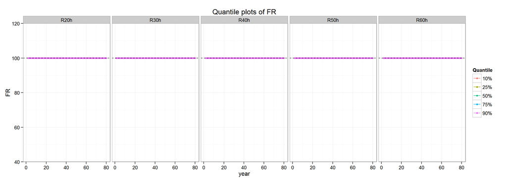

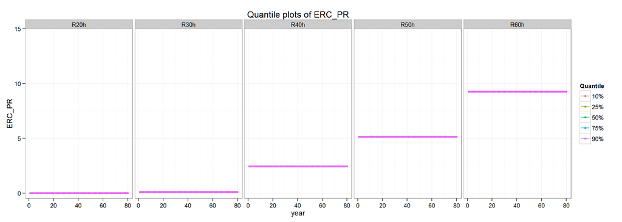

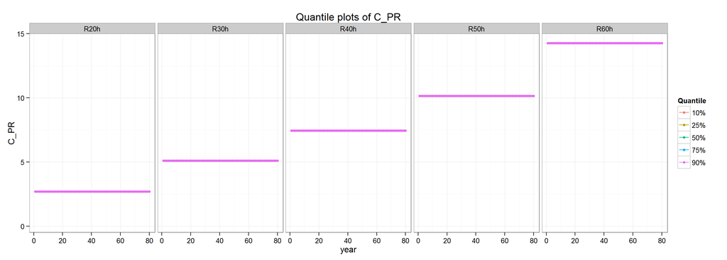

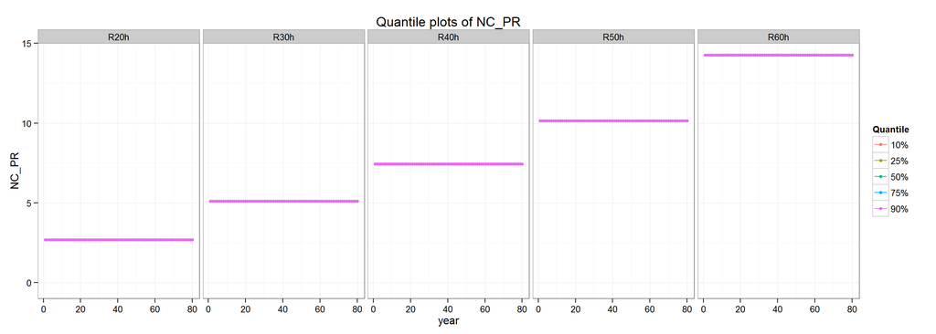

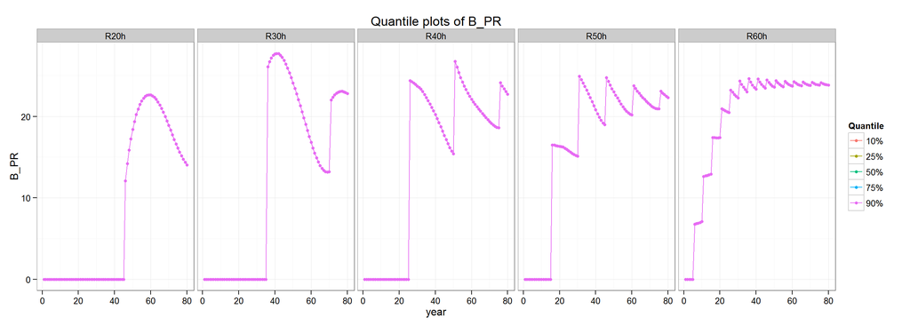

Table for Entry Age 20

| year | AL | MA | AA | FR | UAAL | NC | SC | ADC | EEC | ERC | C | ADC_PR | C_PR | ERC_PR | PR | B | i.r |
| --- | --- | --- | --- | --- | --- | --- | --- | --- | --- | --- | --- | --- | --- | --- | --- | --- | --- |
| 1 | 0.00 | 0.00 | 0.00 | NaN | 0 | 334.36 | 0 | 334.36 | 334.36 | 0 | 334.36 | 2.69 | 2.69 | 0 | 12409.00 | 0.00 | 0.08 |
| 2 | 359.44 | 359.44 | 359.44 | 100 | 0 | 354.40 | 0 | 354.40 | 354.40 | 0 | 354.40 | 2.69 | 2.69 | 0 | 13152.71 | 0.00 | 0.08 |
| 3 | 767.37 | 767.37 | 767.37 | 100 | 0 | 372.56 | 0 | 372.56 | 372.56 | 0 | 372.56 | 2.69 | 2.69 | 0 | 13826.74 | 0.00 | 0.08 |
| 4 | 1225.43 | 1225.43 | 1225.43 | 100 | 0 | 388.59 | 0 | 388.59 | 388.59 | 0 | 388.59 | 2.69 | 2.69 | 0 | 14421.55 | 0.00 | 0.08 |
| 5 | 1735.07 | 1735.07 | 1735.07 | 100 | 0 | 403.93 | 0 | 403.93 | 403.93 | 0 | 403.93 | 2.69 | 2.69 | 0 | 14990.95 | 0.00 | 0.08 |
| 6 | 2299.42 | 2299.42 | 2299.42 | 100 | 0 | 419.00 | 0 | 419.00 | 419.00 | 0 | 419.00 | 2.69 | 2.69 | 0 | 15550.35 | 0.00 | 0.08 |
| 7 | 2922.30 | 2922.30 | 2922.30 | 100 | 0 | 434.15 | 0 | 434.15 | 434.15 | 0 | 434.15 | 2.69 | 2.69 | 0 | 16112.62 | 0.00 | 0.08 |
| 8 | 3608.19 | 3608.19 | 3608.19 | 100 | 0 | 449.37 | 0 | 449.37 | 449.37 | 0 | 449.37 | 2.69 | 2.69 | 0 | 16677.43 | 0.00 | 0.08 |
| 9 | 4361.88 | 4361.88 | 4361.88 | 100 | 0 | 464.77 | 0 | 464.77 | 464.77 | 0 | 464.77 | 2.69 | 2.69 | 0 | 17248.75 | 0.00 | 0.08 |
| 10 | 5188.64 | 5188.64 | 5188.64 | 100 | 0 | 480.70 | 0 | 480.70 | 480.70 | 0 | 480.70 | 2.69 | 2.69 | 0 | 17840.09 | 0.00 | 0.08 |
| 11 | 6094.55 | 6094.55 | 6094.55 | 100 | 0 | 496.73 | 0 | 496.73 | 496.73 | 0 | 496.73 | 2.69 | 2.69 | 0 | 18434.91 | 0.00 | 0.08 |
| 12 | 7085.62 | 7085.62 | 7085.62 | 100 | 0 | 512.92 | 0 | 512.92 | 512.92 | 0 | 512.92 | 2.69 | 2.69 | 0 | 19035.74 | 0.00 | 0.08 |
| 13 | 8168.42 | 8168.42 | 8168.42 | 100 | 0 | 529.42 | 0 | 529.42 | 529.42 | 0 | 529.42 | 2.69 | 2.69 | 0 | 19648.18 | 0.00 | 0.08 |
| 14 | 9350.18 | 9350.18 | 9350.18 | 100 | 0 | 546.34 | 0 | 546.34 | 546.34 | 0 | 546.34 | 2.69 | 2.69 | 0 | 20276.30 | 0.00 | 0.08 |
| 15 | 10638.76 | 10638.76 | 10638.76 | 100 | 0 | 563.80 | 0 | 563.80 | 563.80 | 0 | 563.80 | 2.69 | 2.69 | 0 | 20924.13 | 0.00 | 0.08 |
| 16 | 12042.75 | 12042.75 | 12042.75 | 100 | 0 | 581.79 | 0 | 581.79 | 581.79 | 0 | 581.79 | 2.69 | 2.69 | 0 | 21591.89 | 0.00 | 0.08 |
| 17 | 13571.39 | 13571.39 | 13571.39 | 100 | 0 | 600.33 | 0 | 600.33 | 600.33 | 0 | 600.33 | 2.69 | 2.69 | 0 | 22279.97 | 0.00 | 0.08 |
| 18 | 15234.60 | 15234.60 | 15234.60 | 100 | 0 | 619.40 | 0 | 619.40 | 619.40 | 0 | 619.40 | 2.69 | 2.69 | 0 | 22987.54 | 0.00 | 0.08 |
| 19 | 17043.04 | 17043.04 | 17043.04 | 100 | 0 | 638.94 | 0 | 638.94 | 638.94 | 0 | 638.94 | 2.69 | 2.69 | 0 | 23712.81 | 0.00 | 0.08 |
| 20 | 19008.13 | 19008.13 | 19008.13 | 100 | 0 | 658.98 | 0 | 658.98 | 658.98 | 0 | 658.98 | 2.69 | 2.69 | 0 | 24456.62 | 0.00 | 0.08 |
| 21 | 21142.14 | 21142.14 | 21142.14 | 100 | 0 | 679.54 | 0 | 679.54 | 679.54 | 0 | 679.54 | 2.69 | 2.69 | 0 | 25219.66 | 0.00 | 0.08 |
| 22 | 23458.31 | 23458.31 | 23458.31 | 100 | 0 | 700.66 | 0 | 700.66 | 700.66 | 0 | 700.66 | 2.69 | 2.69 | 0 | 26003.56 | 0.00 | 0.08 |
| 23 | 25970.90 | 25970.90 | 25970.90 | 100 | 0 | 722.35 | 0 | 722.35 | 722.35 | 0 | 722.35 | 2.69 | 2.69 | 0 | 26808.48 | 0.00 | 0.08 |
| 24 | 28695.24 | 28695.24 | 28695.24 | 100 | 0 | 744.63 | 0 | 744.63 | 744.63 | 0 | 744.63 | 2.69 | 2.69 | 0 | 27635.23 | 0.00 | 0.08 |
| 25 | 31647.86 | 31647.86 | 31647.86 | 100 | 0 | 767.52 | 0 | 767.52 | 767.52 | 0 | 767.52 | 2.69 | 2.69 | 0 | 28484.71 | 0.00 | 0.08 |
| 26 | 34846.53 | 34846.53 | 34846.53 | 100 | 0 | 791.04 | 0 | 791.04 | 791.04 | 0 | 791.04 | 2.69 | 2.69 | 0 | 29357.79 | 0.00 | 0.08 |
| 27 | 38310.40 | 38310.40 | 38310.40 | 100 | 0 | 815.23 | 0 | 815.23 | 815.23 | 0 | 815.23 | 2.69 | 2.69 | 0 | 30255.32 | 0.00 | 0.08 |
| 28 | 42060.04 | 42060.04 | 42060.04 | 100 | 0 | 840.09 | 0 | 840.09 | 840.09 | 0 | 840.09 | 2.69 | 2.69 | 0 | 31178.16 | 0.00 | 0.08 |
| 29 | 46117.65 | 46117.65 | 46117.65 | 100 | 0 | 865.66 | 0 | 865.66 | 865.66 | 0 | 865.66 | 2.69 | 2.69 | 0 | 32127.18 | 0.00 | 0.08 |
| 30 | 50507.06 | 50507.06 | 50507.06 | 100 | 0 | 891.96 | 0 | 891.96 | 891.96 | 0 | 891.96 | 2.69 | 2.69 | 0 | 33103.17 | 0.00 | 0.08 |

[output cut: 75 more lines]

Table for Entry Age 30

| year | AL | MA | AA | FR | UAAL | NC | SC | ADC | EEC | ERC | C | ADC_PR | C_PR | ERC_PR | PR | B | i.r |
| --- | --- | --- | --- | --- | --- | --- | --- | --- | --- | --- | --- | --- | --- | --- | --- | --- | --- |
| 1 | 0.00 | 0.00 | 0.00 | 100 | 0 | 1624.81 | 0 | 1624.81 | 1591.04 | 33.77 | 1624.81 | 5.11 | 5.11 | 0.11 | 31820.81 | 0.00 | 0.08 |
| 2 | 1746.67 | 1746.67 | 1746.67 | 100 | 0 | 1677.05 | 0 | 1677.05 | 1642.19 | 34.85 | 1677.05 | 5.11 | 5.11 | 0.11 | 32843.83 | 0.00 | 0.08 |
| 3 | 3680.49 | 3680.49 | 3680.49 | 100 | 0 | 1729.58 | 0 | 1729.58 | 1693.63 | 35.95 | 1729.58 | 5.11 | 5.11 | 0.11 | 33872.66 | 0.00 | 0.08 |
| 4 | 5815.83 | 5815.83 | 5815.83 | 100 | 0 | 1783.44 | 0 | 1783.44 | 1746.37 | 37.06 | 1783.44 | 5.11 | 5.11 | 0.11 | 34927.43 | 0.00 | 0.08 |
| 5 | 8169.21 | 8169.21 | 8169.21 | 100 | 0 | 1839.25 | 0 | 1839.25 | 1801.03 | 38.22 | 1839.25 | 5.11 | 5.11 | 0.11 | 36020.50 | 0.00 | 0.08 |
| 6 | 10759.09 | 10759.09 | 10759.09 | 100 | 0 | 1897.23 | 0 | 1897.23 | 1857.80 | 39.43 | 1897.23 | 5.11 | 5.11 | 0.11 | 37156.08 | 0.00 | 0.08 |
| 7 | 13605.55 | 13605.55 | 13605.55 | 100 | 0 | 1957.24 | 0 | 1957.24 | 1916.56 | 40.68 | 1957.24 | 5.11 | 5.11 | 0.11 | 38331.19 | 0.00 | 0.08 |
| 8 | 16730.00 | 16730.00 | 16730.00 | 100 | 0 | 2018.81 | 0 | 2018.81 | 1976.85 | 41.96 | 2018.81 | 5.11 | 5.11 | 0.11 | 39536.99 | 0.00 | 0.08 |
| 9 | 20154.96 | 20154.96 | 20154.96 | 100 | 0 | 2081.57 | 0 | 2081.57 | 2038.31 | 43.26 | 2081.57 | 5.11 | 5.11 | 0.11 | 40766.19 | 0.00 | 0.08 |
| 10 | 23904.27 | 23904.27 | 23904.27 | 100 | 0 | 2145.42 | 0 | 2145.42 | 2100.83 | 44.59 | 2145.42 | 5.11 | 5.11 | 0.11 | 42016.69 | 0.00 | 0.08 |
| 11 | 28003.42 | 28003.42 | 28003.42 | 100 | 0 | 2210.46 | 0 | 2210.46 | 2164.52 | 45.94 | 2210.46 | 5.11 | 5.11 | 0.11 | 43290.45 | 0.00 | 0.08 |
| 12 | 32479.93 | 32479.93 | 32479.93 | 100 | 0 | 2277.04 | 0 | 2277.04 | 2229.71 | 47.32 | 2277.04 | 5.11 | 5.11 | 0.11 | 44594.28 | 0.00 | 0.08 |
| 13 | 37363.74 | 37363.74 | 37363.74 | 100 | 0 | 2345.55 | 0 | 2345.55 | 2296.80 | 48.75 | 2345.55 | 5.11 | 5.11 | 0.11 | 45936.07 | 0.00 | 0.08 |
| 14 | 42687.48 | 42687.48 | 42687.48 | 100 | 0 | 2416.07 | 0 | 2416.07 | 2365.86 | 50.21 | 2416.07 | 5.11 | 5.11 | 0.11 | 47317.14 | 0.00 | 0.08 |
| 15 | 48486.32 | 48486.32 | 48486.32 | 100 | 0 | 2488.66 | 0 | 2488.66 | 2436.94 | 51.72 | 2488.66 | 5.11 | 5.11 | 0.11 | 48738.84 | 0.00 | 0.08 |
| 16 | 54798.11 | 54798.11 | 54798.11 | 100 | 0 | 2563.40 | 0 | 2563.40 | 2510.12 | 53.27 | 2563.40 | 5.11 | 5.11 | 0.11 | 50202.47 | 0.00 | 0.08 |
| 17 | 61663.62 | 61663.62 | 61663.62 | 100 | 0 | 2640.34 | 0 | 2640.34 | 2585.47 | 54.87 | 2640.34 | 5.11 | 5.11 | 0.11 | 51709.39 | 0.00 | 0.08 |
| 18 | 69126.76 | 69126.76 | 69126.76 | 100 | 0 | 2719.57 | 0 | 2719.57 | 2663.05 | 56.52 | 2719.57 | 5.11 | 5.11 | 0.11 | 53260.98 | 0.00 | 0.08 |
| 19 | 77234.80 | 77234.80 | 77234.80 | 100 | 0 | 2801.15 | 0 | 2801.15 | 2742.94 | 58.22 | 2801.15 | 5.11 | 5.11 | 0.11 | 54858.72 | 0.00 | 0.08 |
| 20 | 86038.65 | 86038.65 | 86038.65 | 100 | 0 | 2885.17 | 0 | 2885.17 | 2825.20 | 59.96 | 2885.17 | 5.11 | 5.11 | 0.11 | 56504.07 | 0.00 | 0.08 |
| 21 | 95593.10 | 95593.10 | 95593.10 | 100 | 0 | 2971.69 | 0 | 2971.69 | 2909.93 | 61.76 | 2971.69 | 5.11 | 5.11 | 0.11 | 58198.56 | 0.00 | 0.08 |
| 22 | 105957.15 | 105957.15 | 105957.15 | 100 | 0 | 3060.78 | 0 | 3060.78 | 2997.17 | 63.61 | 3060.78 | 5.11 | 5.11 | 0.11 | 59943.44 | 0.00 | 0.08 |
| 23 | 117194.28 | 117194.28 | 117194.28 | 100 | 0 | 3152.55 | 0 | 3152.55 | 3087.03 | 65.52 | 3152.55 | 5.11 | 5.11 | 0.11 | 61740.59 | 0.00 | 0.08 |
| 24 | 129372.84 | 129372.84 | 129372.84 | 100 | 0 | 3247.06 | 0 | 3247.06 | 3179.58 | 67.48 | 3247.06 | 5.11 | 5.11 | 0.11 | 63591.53 | 0.00 | 0.08 |
| 25 | 142566.39 | 142566.39 | 142566.39 | 100 | 0 | 3344.40 | 0 | 3344.40 | 3274.89 | 69.51 | 3344.40 | 5.11 | 5.11 | 0.11 | 65497.88 | 0.00 | 0.08 |
| 26 | 156854.10 | 156854.10 | 156854.10 | 100 | 0 | 3444.66 | 0 | 3444.66 | 3373.07 | 71.59 | 3444.66 | 5.11 | 5.11 | 0.11 | 67461.34 | 0.00 | 0.08 |
| 27 | 172321.17 | 172321.17 | 172321.17 | 100 | 0 | 3547.92 | 0 | 3547.92 | 3474.18 | 73.74 | 3547.92 | 5.11 | 5.11 | 0.11 | 69483.63 | 0.00 | 0.08 |
| 28 | 189059.27 | 189059.27 | 189059.27 | 100 | 0 | 3654.27 | 0 | 3654.27 | 3578.33 | 75.95 | 3654.27 | 5.11 | 5.11 | 0.11 | 71566.51 | 0.00 | 0.08 |
| 29 | 207167.05 | 207167.05 | 207167.05 | 100 | 0 | 3763.81 | 0 | 3763.81 | 3685.59 | 78.22 | 3763.81 | 5.11 | 5.11 | 0.11 | 73711.71 | 0.00 | 0.08 |
| 30 | 226750.68 | 226750.68 | 226750.68 | 100 | 0 | 3876.62 | 0 | 3876.62 | 3796.05 | 80.57 | 3876.62 | 5.11 | 5.11 | 0.11 | 75921.00 | 0.00 | 0.08 |

[output cut: 75 more lines]

Table for Entry Age 40

| year | AL | MA | AA | FR | UAAL | NC | SC | ADC | EEC | ERC | C | ADC_PR | C_PR | ERC_PR | PR | B | i.r |
| --- | --- | --- | --- | --- | --- | --- | --- | --- | --- | --- | --- | --- | --- | --- | --- | --- | --- |
| 1 | 0.00 | 0.00 | 0.00 | NaN | 0 | 2265.46 | 0 | 2265.46 | 1520.60 | 744.85 | 2265.46 | 7.45 | 7.45 | 2.45 | 30412.02 | 0.00 | 0.08 |
| 2 | 2435.36 | 2435.36 | 2435.36 | 100 | 0 | 2333.42 | 0 | 2333.42 | 1566.22 | 767.20 | 2333.42 | 7.45 | 7.45 | 2.45 | 31324.38 | 0.00 | 0.08 |
| 3 | 5126.44 | 5126.44 | 5126.44 | 100 | 0 | 2403.42 | 0 | 2403.42 | 1613.21 | 790.22 | 2403.42 | 7.45 | 7.45 | 2.45 | 32264.11 | 0.00 | 0.08 |
| 4 | 8094.60 | 8094.60 | 8094.60 | 100 | 0 | 2475.52 | 0 | 2475.52 | 1661.60 | 813.92 | 2475.52 | 7.45 | 7.45 | 2.45 | 33232.04 | 0.00 | 0.08 |
| 5 | 11362.89 | 11362.89 | 11362.89 | 100 | 0 | 2549.79 | 0 | 2549.79 | 1711.45 | 838.34 | 2549.79 | 7.45 | 7.45 | 2.45 | 34229.00 | 0.00 | 0.08 |
| 6 | 14956.13 | 14956.13 | 14956.13 | 100 | 0 | 2626.28 | 0 | 2626.28 | 1762.79 | 863.49 | 2626.28 | 7.45 | 7.45 | 2.45 | 35255.87 | 0.00 | 0.08 |
| 7 | 18901.09 | 18901.09 | 18901.09 | 100 | 0 | 2705.07 | 0 | 2705.07 | 1815.68 | 889.39 | 2705.07 | 7.45 | 7.45 | 2.45 | 36313.54 | 0.00 | 0.08 |
| 8 | 23226.63 | 23226.63 | 23226.63 | 100 | 0 | 2786.22 | 0 | 2786.22 | 1870.15 | 916.08 | 2786.22 | 7.45 | 7.45 | 2.45 | 37402.95 | 0.00 | 0.08 |
| 9 | 27963.81 | 27963.81 | 27963.81 | 100 | 0 | 2869.81 | 0 | 2869.81 | 1926.25 | 943.56 | 2869.81 | 7.45 | 7.45 | 2.45 | 38525.04 | 0.00 | 0.08 |
| 10 | 33146.15 | 33146.15 | 33146.15 | 100 | 0 | 2955.91 | 0 | 2955.91 | 1984.04 | 971.87 | 2955.91 | 7.45 | 7.45 | 2.45 | 39680.79 | 0.00 | 0.08 |
| 11 | 38809.71 | 38809.71 | 38809.71 | 100 | 0 | 3044.58 | 0 | 3044.58 | 2043.56 | 1001.02 | 3044.58 | 7.45 | 7.45 | 2.45 | 40871.21 | 0.00 | 0.08 |
| 12 | 44993.36 | 44993.36 | 44993.36 | 100 | 0 | 3135.92 | 0 | 3135.92 | 2104.87 | 1031.05 | 3135.92 | 7.45 | 7.45 | 2.45 | 42097.35 | 0.00 | 0.08 |
| 13 | 51738.97 | 51738.97 | 51738.97 | 100 | 0 | 3230.00 | 0 | 3230.00 | 2168.01 | 1061.98 | 3230.00 | 7.45 | 7.45 | 2.45 | 43360.27 | 0.00 | 0.08 |
| 14 | 59091.65 | 59091.65 | 59091.65 | 100 | 0 | 3326.90 | 0 | 3326.90 | 2233.05 | 1093.84 | 3326.90 | 7.45 | 7.45 | 2.45 | 44661.08 | 0.00 | 0.08 |
| 15 | 67099.93 | 67099.93 | 67099.93 | 100 | 0 | 3426.70 | 0 | 3426.70 | 2300.05 | 1126.66 | 3426.70 | 7.45 | 7.45 | 2.45 | 46000.91 | 0.00 | 0.08 |
| 16 | 75816.14 | 75816.14 | 75816.14 | 100 | 0 | 3529.51 | 0 | 3529.51 | 2369.05 | 1160.46 | 3529.51 | 7.45 | 7.45 | 2.45 | 47380.94 | 0.00 | 0.08 |
| 17 | 85296.56 | 85296.56 | 85296.56 | 100 | 0 | 3635.39 | 0 | 3635.39 | 2440.12 | 1195.27 | 3635.39 | 7.45 | 7.45 | 2.45 | 48802.37 | 0.00 | 0.08 |
| 18 | 95601.85 | 95601.85 | 95601.85 | 100 | 0 | 3744.45 | 0 | 3744.45 | 2513.32 | 1231.13 | 3744.45 | 7.45 | 7.45 | 2.45 | 50266.44 | 0.00 | 0.08 |
| 19 | 106797.28 | 106797.28 | 106797.28 | 100 | 0 | 3856.79 | 0 | 3856.79 | 2588.72 | 1268.06 | 3856.79 | 7.45 | 7.45 | 2.45 | 51774.43 | 0.00 | 0.08 |
| 20 | 118953.12 | 118953.12 | 118953.12 | 100 | 0 | 3972.49 | 0 | 3972.49 | 2666.38 | 1306.11 | 3972.49 | 7.45 | 7.45 | 2.45 | 53327.66 | 0.00 | 0.08 |
| 21 | 132145.03 | 132145.03 | 132145.03 | 100 | 0 | 4091.66 | 0 | 4091.66 | 2746.37 | 1345.29 | 4091.66 | 7.45 | 7.45 | 2.45 | 54927.49 | 0.00 | 0.08 |
| 22 | 146454.44 | 146454.44 | 146454.44 | 100 | 0 | 4214.41 | 0 | 4214.41 | 2828.77 | 1385.65 | 4214.41 | 7.45 | 7.45 | 2.45 | 56575.32 | 0.00 | 0.08 |
| 23 | 161969.02 | 161969.02 | 161969.02 | 100 | 0 | 4340.85 | 0 | 4340.85 | 2913.63 | 1427.22 | 4340.85 | 7.45 | 7.45 | 2.45 | 58272.58 | 0.00 | 0.08 |
| 24 | 178783.11 | 178783.11 | 178783.11 | 100 | 0 | 4471.07 | 0 | 4471.07 | 3001.04 | 1470.03 | 4471.07 | 7.45 | 7.45 | 2.45 | 60020.76 | 0.00 | 0.08 |
| 25 | 196998.24 | 196998.24 | 196998.24 | 100 | 0 | 4605.20 | 0 | 4605.20 | 3091.07 | 1514.14 | 4605.20 | 7.45 | 7.45 | 2.45 | 61821.38 | 0.00 | 0.08 |
| 26 | 216723.70 | 216723.70 | 216723.70 | 100 | 0 | 4743.36 | 0 | 4743.36 | 3183.80 | 1559.56 | 4743.36 | 7.45 | 7.45 | 2.45 | 63676.02 | 15535.51 | 0.08 |
| 27 | 221376.42 | 221376.42 | 221376.42 | 100 | 0 | 4885.66 | 0 | 4885.66 | 3279.32 | 1606.35 | 4885.66 | 7.45 | 7.45 | 2.45 | 65586.30 | 15901.68 | 0.08 |
| 28 | 226137.44 | 226137.44 | 226137.44 | 100 | 0 | 5032.23 | 0 | 5032.23 | 3377.69 | 1654.54 | 5032.23 | 7.45 | 7.45 | 2.45 | 67553.89 | 16269.07 | 0.08 |
| 29 | 231018.15 | 231018.15 | 231018.15 | 100 | 0 | 5183.20 | 0 | 5183.20 | 3479.03 | 1704.17 | 5183.20 | 7.45 | 7.45 | 2.45 | 69580.51 | 16638.96 | 0.08 |
| 30 | 236029.56 | 236029.56 | 236029.56 | 100 | 0 | 5338.69 | 0 | 5338.69 | 3583.40 | 1755.30 | 5338.69 | 7.45 | 7.45 | 2.45 | 71667.92 | 17010.94 | 0.08 |

[output cut: 75 more lines]

Table for Entry Age 50

| year | AL | MA | AA | FR | UAAL | NC | SC | ADC | EEC | ERC | C | ADC_PR | C_PR | ERC_PR | PR | B | i.r |
| --- | --- | --- | --- | --- | --- | --- | --- | --- | --- | --- | --- | --- | --- | --- | --- | --- | --- |
| 1 | 0.00 | 0.00 | 0.00 | NaN | 0 | 3116.00 | 0 | 3116.00 | 1535.07 | 1580.94 | 3116.00 | 10.15 | 10.15 | 5.15 | 30701.33 | 0.00 | 0.08 |
| 2 | 3349.70 | 3349.70 | 3349.70 | 100 | 0 | 3209.48 | 0 | 3209.48 | 1581.12 | 1628.37 | 3209.48 | 10.15 | 10.15 | 5.15 | 31622.37 | 0.00 | 0.08 |
| 3 | 7051.13 | 7051.13 | 7051.13 | 100 | 0 | 3305.77 | 0 | 3305.77 | 1628.55 | 1677.22 | 3305.77 | 10.15 | 10.15 | 5.15 | 32571.04 | 0.00 | 0.08 |
| 4 | 11133.66 | 11133.66 | 11133.66 | 100 | 0 | 3404.94 | 0 | 3404.94 | 1677.41 | 1727.53 | 3404.94 | 10.15 | 10.15 | 5.15 | 33548.17 | 0.00 | 0.08 |
| 5 | 15629.00 | 15629.00 | 15629.00 | 100 | 0 | 3507.09 | 0 | 3507.09 | 1727.73 | 1779.36 | 3507.09 | 10.15 | 10.15 | 5.15 | 34554.61 | 0.00 | 0.08 |
| 6 | 20571.29 | 20571.29 | 20571.29 | 100 | 0 | 3612.30 | 0 | 3612.30 | 1779.56 | 1832.74 | 3612.30 | 10.15 | 10.15 | 5.15 | 35591.25 | 0.00 | 0.08 |
| 7 | 25997.36 | 25997.36 | 25997.36 | 100 | 0 | 3720.67 | 0 | 3720.67 | 1832.95 | 1887.72 | 3720.67 | 10.15 | 10.15 | 5.15 | 36658.99 | 0.00 | 0.08 |
| 8 | 31946.89 | 31946.89 | 31946.89 | 100 | 0 | 3832.29 | 0 | 3832.29 | 1887.94 | 1944.35 | 3832.29 | 10.15 | 10.15 | 5.15 | 37758.76 | 0.00 | 0.08 |
| 9 | 38462.62 | 38462.62 | 38462.62 | 100 | 0 | 3947.26 | 0 | 3947.26 | 1944.58 | 2002.68 | 3947.26 | 10.15 | 10.15 | 5.15 | 38891.52 | 0.00 | 0.08 |
| 10 | 45590.62 | 45590.62 | 45590.62 | 100 | 0 | 4065.68 | 0 | 4065.68 | 2002.91 | 2062.76 | 4065.68 | 10.15 | 10.15 | 5.15 | 40058.27 | 0.00 | 0.08 |
| 11 | 53380.52 | 53380.52 | 53380.52 | 100 | 0 | 4187.65 | 0 | 4187.65 | 2063.00 | 2124.65 | 4187.65 | 10.15 | 10.15 | 5.15 | 41260.01 | 0.00 | 0.08 |
| 12 | 61885.78 | 61885.78 | 61885.78 | 100 | 0 | 4313.28 | 0 | 4313.28 | 2124.89 | 2188.39 | 4313.28 | 10.15 | 10.15 | 5.15 | 42497.82 | 0.00 | 0.08 |
| 13 | 71163.98 | 71163.98 | 71163.98 | 100 | 0 | 4442.68 | 0 | 4442.68 | 2188.64 | 2254.04 | 4442.68 | 10.15 | 10.15 | 5.15 | 43772.75 | 0.00 | 0.08 |
| 14 | 81277.16 | 81277.16 | 81277.16 | 100 | 0 | 4575.96 | 0 | 4575.96 | 2254.30 | 2321.66 | 4575.96 | 10.15 | 10.15 | 5.15 | 45085.93 | 0.00 | 0.08 |
| 15 | 92292.10 | 92292.10 | 92292.10 | 100 | 0 | 4713.23 | 0 | 4713.23 | 2321.93 | 2391.31 | 4713.23 | 10.15 | 10.15 | 5.15 | 46438.51 | 0.00 | 0.08 |
| 16 | 104280.73 | 104280.73 | 104280.73 | 100 | 0 | 4854.63 | 0 | 4854.63 | 2391.58 | 2463.05 | 4854.63 | 10.15 | 10.15 | 5.15 | 47831.67 | 7896.96 | 0.08 |
| 17 | 108831.29 | 108831.29 | 108831.29 | 100 | 0 | 5000.27 | 0 | 5000.27 | 2463.33 | 2536.94 | 5000.27 | 10.15 | 10.15 | 5.15 | 49266.62 | 8114.36 | 0.08 |
| 18 | 113645.99 | 113645.99 | 113645.99 | 100 | 0 | 5150.28 | 0 | 5150.28 | 2537.23 | 2613.05 | 5150.28 | 10.15 | 10.15 | 5.15 | 50744.61 | 8335.54 | 0.08 |
| 19 | 118745.28 | 118745.28 | 118745.28 | 100 | 0 | 5304.79 | 0 | 5304.79 | 2613.35 | 2691.44 | 5304.79 | 10.15 | 10.15 | 5.15 | 52266.95 | 8561.37 | 0.08 |
| 20 | 124150.35 | 124150.35 | 124150.35 | 100 | 0 | 5463.93 | 0 | 5463.93 | 2691.75 | 2772.18 | 5463.93 | 10.15 | 10.15 | 5.15 | 53834.96 | 8791.84 | 0.08 |
| 21 | 129884.12 | 129884.12 | 129884.12 | 100 | 0 | 5627.85 | 0 | 5627.85 | 2772.50 | 2855.35 | 5627.85 | 10.15 | 10.15 | 5.15 | 55450.01 | 9026.80 | 0.08 |
| 22 | 135971.56 | 135971.56 | 135971.56 | 100 | 0 | 5796.68 | 0 | 5796.68 | 2855.68 | 2941.01 | 5796.68 | 10.15 | 10.15 | 5.15 | 57113.51 | 9266.01 | 0.08 |
| 23 | 142439.90 | 142439.90 | 142439.90 | 100 | 0 | 5970.58 | 0 | 5970.58 | 2941.35 | 3029.24 | 5970.58 | 10.15 | 10.15 | 5.15 | 58826.91 | 9463.31 | 0.08 |
| 24 | 149368.21 | 149368.21 | 149368.21 | 100 | 0 | 6149.70 | 0 | 6149.70 | 3029.59 | 3120.12 | 6149.70 | 10.15 | 10.15 | 5.15 | 60591.72 | 9657.79 | 0.08 |
| 25 | 156799.63 | 156799.63 | 156799.63 | 100 | 0 | 6334.19 | 0 | 6334.19 | 3120.47 | 3213.72 | 6334.19 | 10.15 | 10.15 | 5.15 | 62409.47 | 9850.04 | 0.08 |
| 26 | 164780.07 | 164780.07 | 164780.07 | 100 | 0 | 6524.22 | 0 | 6524.22 | 3214.09 | 3310.13 | 6524.22 | 10.15 | 10.15 | 5.15 | 64281.76 | 10042.71 | 0.08 |
| 27 | 173356.20 | 173356.20 | 173356.20 | 100 | 0 | 6719.95 | 0 | 6719.95 | 3310.51 | 3409.43 | 6719.95 | 10.15 | 10.15 | 5.15 | 66210.21 | 10240.28 | 0.08 |
| 28 | 182573.55 | 182573.55 | 182573.55 | 100 | 0 | 6921.54 | 0 | 6921.54 | 3409.83 | 3511.72 | 6921.54 | 10.15 | 10.15 | 5.15 | 68196.52 | 10448.74 | 0.08 |
| 29 | 192474.83 | 192474.83 | 192474.83 | 100 | 0 | 7129.19 | 0 | 7129.19 | 3512.12 | 3617.07 | 7129.19 | 10.15 | 10.15 | 5.15 | 70242.41 | 10675.39 | 0.08 |
| 30 | 203098.28 | 203098.28 | 203098.28 | 100 | 0 | 7343.07 | 0 | 7343.07 | 3617.48 | 3725.58 | 7343.07 | 10.15 | 10.15 | 5.15 | 72349.69 | 10928.40 | 0.08 |

[output cut: 75 more lines]

Table for Entry Age 60

| year | AL | MA | AA | FR | UAAL | NC | SC | ADC | EEC | ERC | C | ADC_PR | C_PR | ERC_PR | PR | B | i.r |
| --- | --- | --- | --- | --- | --- | --- | --- | --- | --- | --- | --- | --- | --- | --- | --- | --- | --- |
| 1 | 0.00 | 0.00 | 0.00 | NaN | 0 | 4560.67 | 0 | 4560.67 | 1598.21 | 2962.45 | 4560.67 | 14.27 | 14.27 | 9.27 | 31964.27 | 0.00 | 0.08 |
| 2 | 4902.72 | 4902.72 | 4902.72 | 100 | 0 | 4697.49 | 0 | 4697.49 | 1646.16 | 3051.33 | 4697.49 | 14.27 | 14.27 | 9.27 | 32923.19 | 0.00 | 0.08 |
| 3 | 10320.22 | 10320.22 | 10320.22 | 100 | 0 | 4838.41 | 0 | 4838.41 | 1695.54 | 3142.87 | 4838.41 | 14.27 | 14.27 | 9.27 | 33910.89 | 0.00 | 0.08 |
| 4 | 16295.53 | 16295.53 | 16295.53 | 100 | 0 | 4983.56 | 0 | 4983.56 | 1746.41 | 3237.15 | 4983.56 | 14.27 | 14.27 | 9.27 | 34928.22 | 0.00 | 0.08 |
| 5 | 22875.03 | 22875.03 | 22875.03 | 100 | 0 | 5133.07 | 0 | 5133.07 | 1798.80 | 3334.27 | 5133.07 | 14.27 | 14.27 | 9.27 | 35976.06 | 0.00 | 0.08 |
| 6 | 30108.71 | 30108.71 | 30108.71 | 100 | 0 | 5287.06 | 0 | 5287.06 | 1852.77 | 3434.30 | 5287.06 | 14.27 | 14.27 | 9.27 | 37055.34 | 2512.56 | 0.08 |
| 7 | 35349.45 | 35349.45 | 35349.45 | 100 | 0 | 5445.68 | 0 | 5445.68 | 1908.35 | 3537.33 | 5445.68 | 14.27 | 14.27 | 9.27 | 38167.00 | 2606.80 | 0.08 |
| 8 | 41052.45 | 41052.45 | 41052.45 | 100 | 0 | 5609.05 | 0 | 5609.05 | 1965.60 | 3643.44 | 5609.05 | 14.27 | 14.27 | 9.27 | 39312.02 | 2710.05 | 0.08 |
| 9 | 47247.80 | 47247.80 | 47247.80 | 100 | 0 | 5777.32 | 0 | 5777.32 | 2024.57 | 3752.75 | 5777.32 | 14.27 | 14.27 | 9.27 | 40491.38 | 2825.00 | 0.08 |
| 10 | 53965.12 | 53965.12 | 53965.12 | 100 | 0 | 5950.64 | 0 | 5950.64 | 2085.31 | 3865.33 | 5950.64 | 14.27 | 14.27 | 9.27 | 41706.12 | 2954.77 | 0.08 |
| 11 | 61233.06 | 61233.06 | 61233.06 | 100 | 0 | 6129.16 | 0 | 6129.16 | 2147.87 | 3981.29 | 6129.16 | 14.27 | 14.27 | 9.27 | 42957.30 | 5430.10 | 0.08 |
| 12 | 66577.02 | 66577.02 | 66577.02 | 100 | 0 | 6313.03 | 0 | 6313.03 | 2212.30 | 4100.73 | 6313.03 | 14.27 | 14.27 | 9.27 | 44246.02 | 5619.11 | 0.08 |
| 13 | 72316.26 | 72316.26 | 72316.26 | 100 | 0 | 6502.42 | 0 | 6502.42 | 2278.67 | 4223.75 | 6502.42 | 14.27 | 14.27 | 9.27 | 45573.40 | 5809.91 | 0.08 |
| 14 | 78484.43 | 78484.43 | 78484.43 | 100 | 0 | 6697.49 | 0 | 6697.49 | 2347.03 | 4350.46 | 6697.49 | 14.27 | 14.27 | 9.27 | 46940.60 | 6019.07 | 0.08 |
| 15 | 85100.07 | 85100.07 | 85100.07 | 100 | 0 | 6898.42 | 0 | 6898.42 | 2417.44 | 4480.98 | 6898.42 | 14.27 | 14.27 | 9.27 | 48348.82 | 6251.64 | 0.08 |
| 16 | 92177.86 | 92177.86 | 92177.86 | 100 | 0 | 7105.37 | 0 | 7105.37 | 2489.96 | 4615.41 | 7105.37 | 14.27 | 14.27 | 9.27 | 49799.28 | 8668.96 | 0.08 |
| 17 | 97410.34 | 97410.34 | 97410.34 | 100 | 0 | 7318.53 | 0 | 7318.53 | 2564.66 | 4753.87 | 7318.53 | 14.27 | 14.27 | 9.27 | 51293.26 | 8920.05 | 0.08 |
| 18 | 102994.48 | 102994.48 | 102994.48 | 100 | 0 | 7538.09 | 0 | 7538.09 | 2641.60 | 4896.49 | 7538.09 | 14.27 | 14.27 | 9.27 | 52832.06 | 9175.52 | 0.08 |
| 19 | 108958.83 | 108958.83 | 108958.83 | 100 | 0 | 7764.23 | 0 | 7764.23 | 2720.85 | 5043.38 | 7764.23 | 14.27 | 14.27 | 9.27 | 54417.02 | 9452.80 | 0.08 |
| 20 | 115315.53 | 115315.53 | 115315.53 | 100 | 0 | 7997.16 | 0 | 7997.16 | 2802.48 | 5194.68 | 7997.16 | 14.27 | 14.27 | 9.27 | 56049.53 | 9758.39 | 0.08 |
| 21 | 122070.87 | 122070.87 | 122070.87 | 100 | 0 | 8237.07 | 0 | 8237.07 | 2886.55 | 5350.52 | 8237.07 | 14.27 | 14.27 | 9.27 | 57731.02 | 12096.22 | 0.08 |
| 22 | 127077.60 | 127077.60 | 127077.60 | 100 | 0 | 8484.18 | 0 | 8484.18 | 2973.15 | 5511.04 | 8484.18 | 14.27 | 14.27 | 9.27 | 59462.95 | 12379.43 | 0.08 |
| 23 | 132421.02 | 132421.02 | 132421.02 | 100 | 0 | 8738.71 | 0 | 8738.71 | 3062.34 | 5676.37 | 8738.71 | 14.27 | 14.27 | 9.27 | 61246.84 | 12666.86 | 0.08 |
| 24 | 138129.84 | 138129.84 | 138129.84 | 100 | 0 | 9000.87 | 0 | 9000.87 | 3154.21 | 5846.66 | 9000.87 | 14.27 | 14.27 | 9.27 | 63084.24 | 12976.66 | 0.08 |
| 25 | 144215.61 | 144215.61 | 144215.61 | 100 | 0 | 9270.90 | 0 | 9270.90 | 3248.84 | 6022.06 | 9270.90 | 14.27 | 14.27 | 9.27 | 64976.77 | 13316.85 | 0.08 |
| 26 | 150682.38 | 150682.38 | 150682.38 | 100 | 0 | 9549.02 | 0 | 9549.02 | 3346.30 | 6202.72 | 9549.02 | 14.27 | 14.27 | 9.27 | 66926.07 | 15545.74 | 0.08 |
| 27 | 155537.08 | 155537.08 | 155537.08 | 100 | 0 | 9835.50 | 0 | 9835.50 | 3446.69 | 6388.80 | 9835.50 | 14.27 | 14.27 | 9.27 | 68933.86 | 15825.69 | 0.08 |
| 28 | 160762.91 | 160762.91 | 160762.91 | 100 | 0 | 10130.56 | 0 | 10130.56 | 3550.09 | 6580.47 | 10130.56 | 14.27 | 14.27 | 9.27 | 71001.87 | 16110.71 | 0.08 |
| 29 | 166391.47 | 166391.47 | 166391.47 | 100 | 0 | 10434.48 | 0 | 10434.48 | 3656.60 | 6777.88 | 10434.48 | 14.27 | 14.27 | 9.27 | 73131.93 | 16420.73 | 0.08 |
| 30 | 172435.61 | 172435.61 | 172435.61 | 100 | 0 | 10747.51 | 0 | 10747.51 | 3766.29 | 6981.22 | 10747.51 | 14.27 | 14.27 | 9.27 | 75325.89 | 16766.45 | 0.08 |

[output cut: 75 more lines]

# Scenario 3

Rxxhs Single cell 20 - 60, with new entrants, stochastic return, starting off fully funded, no restriction

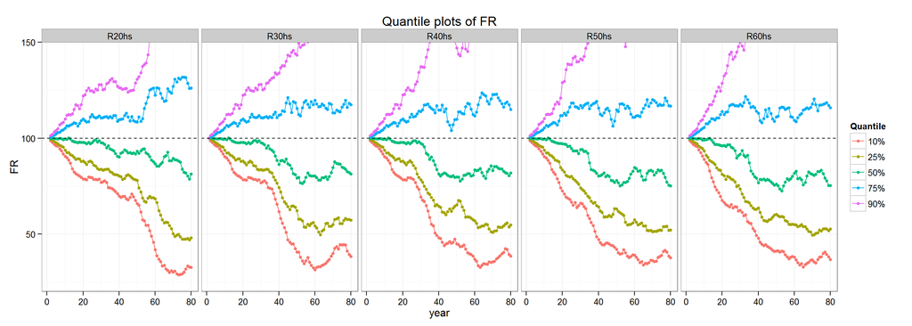

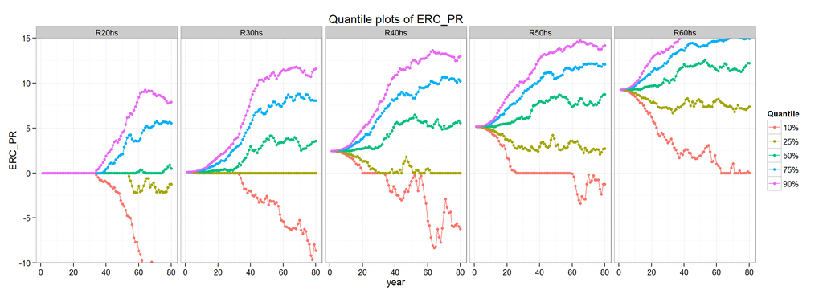

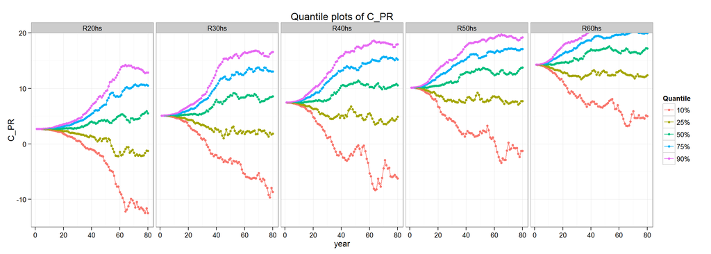

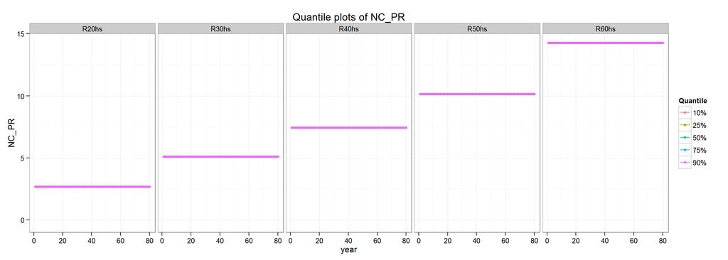

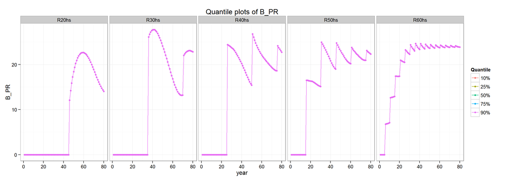

Plots for simulation 3.

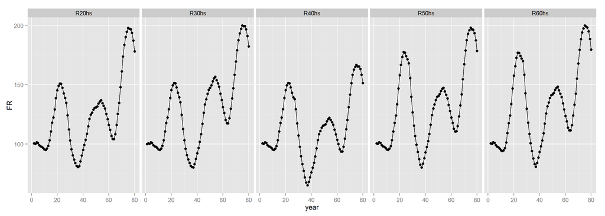

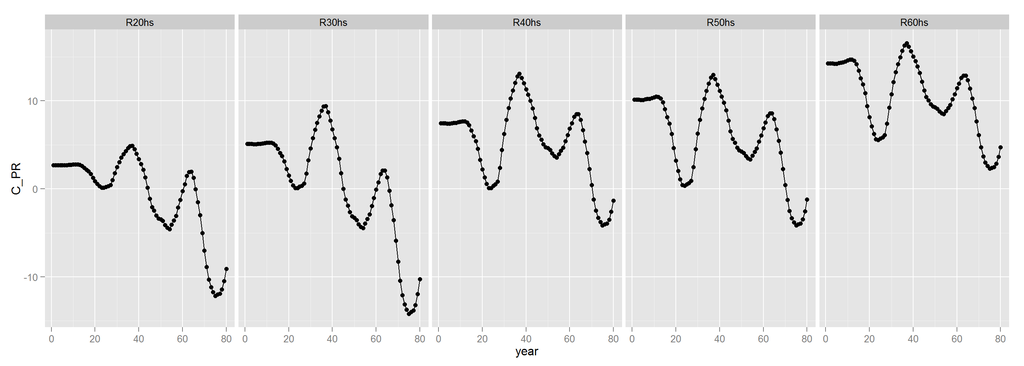

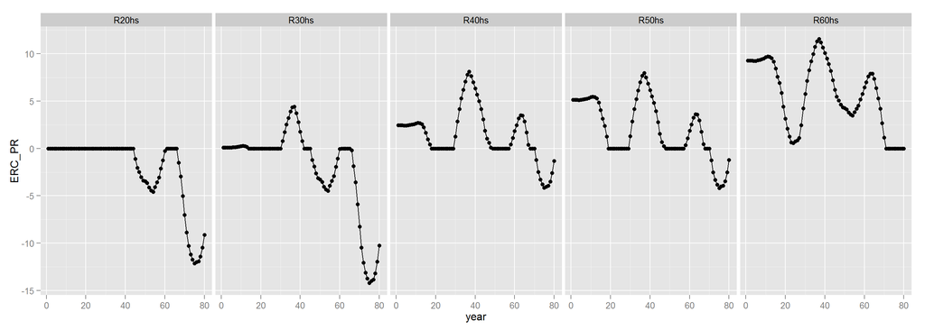

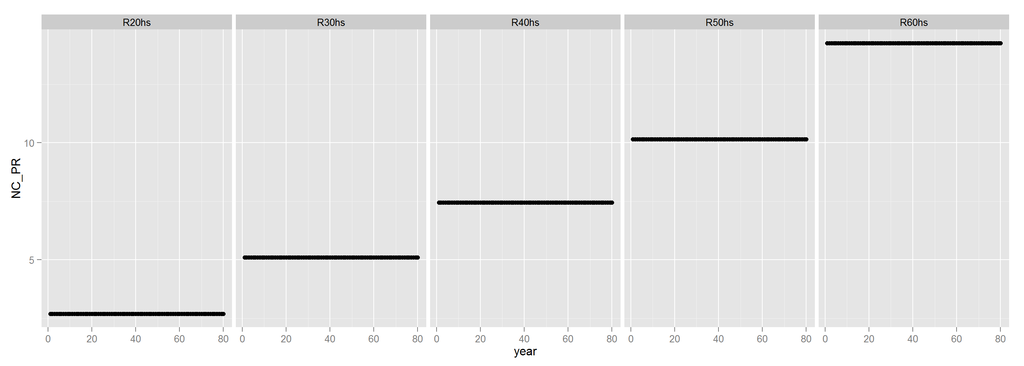

Table for Entry Age 20

| year | AL | MA | AA | FR | UAAL | NC | SC | ADC | EEC | ERC | C | ADC_PR | C_PR | ERC_PR | PR | B | i.r |
| --- | --- | --- | --- | --- | --- | --- | --- | --- | --- | --- | --- | --- | --- | --- | --- | --- | --- |
| 1 | 0.00 | 0.00 | 0.00 | NaN | 0.00 | 334.36 | 0.00 | 334.36 | 334.36 | 0.00 | 334.36 | 2.69 | 2.69 | 0.00 | 12409.00 | 0.00 | 0.13 |
| 2 | 359.44 | 376.21 | 361.11 | 100.47 | -1.68 | 354.40 | -0.09 | 354.31 | 354.31 | 0.00 | 354.31 | 2.69 | 2.69 | 0.00 | 13152.71 | 0.00 | 0.03 |
| 3 | 767.37 | 750.23 | 768.38 | 100.13 | -1.01 | 372.56 | -0.05 | 372.51 | 372.51 | 0.00 | 372.51 | 2.69 | 2.69 | 0.00 | 13826.74 | 0.00 | 0.25 |
| 4 | 1225.43 | 1408.15 | 1243.39 | 101.47 | -17.96 | 388.59 | -0.93 | 387.66 | 387.66 | 0.00 | 387.66 | 2.69 | 2.69 | 0.00 | 14421.55 | 0.00 | -0.12 |
| 5 | 1735.07 | 1584.18 | 1749.39 | 100.83 | -14.32 | 403.93 | -0.74 | 403.19 | 403.19 | 0.00 | 403.19 | 2.69 | 2.69 | 0.00 | 14990.95 | 0.00 | 0.03 |
| 6 | 2299.42 | 2037.27 | 2275.37 | 98.95 | 24.05 | 419.00 | 1.24 | 420.25 | 420.25 | 0.00 | 420.25 | 2.70 | 2.70 | 0.00 | 15550.35 | 0.00 | 0.13 |
| 7 | 2922.30 | 2766.28 | 2866.12 | 98.08 | 56.18 | 434.15 | 2.91 | 437.06 | 437.06 | 0.00 | 437.06 | 2.71 | 2.71 | 0.00 | 16112.62 | 0.00 | 0.06 |
| 8 | 3608.19 | 3385.26 | 3523.79 | 97.66 | 84.41 | 449.37 | 4.37 | 453.74 | 453.74 | 0.00 | 453.74 | 2.72 | 2.72 | 0.00 | 16677.43 | 0.00 | 0.00 |
| 9 | 4361.88 | 3847.68 | 4217.88 | 96.70 | 144.00 | 464.77 | 7.45 | 472.21 | 472.21 | 0.00 | 472.21 | 2.74 | 2.74 | 0.00 | 17248.75 | 0.00 | 0.04 |
| 10 | 5188.64 | 4485.92 | 4950.72 | 95.41 | 237.93 | 480.70 | 12.30 | 493.00 | 493.00 | 0.00 | 493.00 | 2.76 | 2.76 | 0.00 | 17840.09 | 0.00 | 0.15 |
| 11 | 6094.55 | 5728.47 | 5791.39 | 95.03 | 303.15 | 496.73 | 15.68 | 512.41 | 512.41 | 0.00 | 512.41 | 2.78 | 2.78 | 0.00 | 18434.91 | 0.00 | 0.18 |
| 12 | 7085.62 | 7379.35 | 6811.47 | 96.13 | 274.14 | 512.92 | 14.18 | 527.09 | 527.09 | 0.00 | 527.09 | 2.77 | 2.77 | 0.00 | 19035.74 | 0.00 | 0.15 |
| 13 | 8168.42 | 9125.81 | 8037.31 | 98.39 | 131.12 | 529.42 | 6.78 | 536.20 | 536.20 | 0.00 | 536.20 | 2.73 | 2.73 | 0.00 | 19648.18 | 0.00 | 0.35 |
| 14 | 9350.18 | 13022.64 | 9647.39 | 103.18 | -297.21 | 546.34 | -15.37 | 530.97 | 530.97 | 0.00 | 530.97 | 2.62 | 2.62 | 0.00 | 20276.30 | 0.00 | 0.22 |
| 15 | 10638.76 | 16478.74 | 11769.61 | 110.63 | -1130.85 | 563.80 | -58.48 | 505.31 | 505.31 | 0.00 | 505.31 | 2.41 | 2.41 | 0.00 | 20924.13 | 0.00 | 0.11 |
| 16 | 12042.75 | 18844.24 | 14192.01 | 117.85 | -2149.26 | 581.79 | -111.15 | 470.64 | 470.64 | 0.00 | 470.64 | 2.18 | 2.18 | 0.00 | 21591.89 | 0.00 | 0.00 |
| 17 | 13571.39 | 19234.29 | 16589.18 | 122.24 | -3017.79 | 600.33 | -156.07 | 444.26 | 444.26 | 0.00 | 444.26 | 1.99 | 1.99 | 0.00 | 22279.97 | 0.00 | 0.43 |
| 18 | 15234.60 | 28047.77 | 19682.41 | 129.20 | -4447.81 | 619.40 | -230.03 | 389.37 | 389.37 | 0.00 | 389.37 | 1.69 | 1.69 | 0.00 | 22987.54 | 0.00 | 0.16 |
| 19 | 17043.04 | 32881.57 | 23636.73 | 138.69 | -6593.69 | 638.94 | -341.01 | 297.93 | 297.93 | 0.00 | 297.93 | 1.26 | 1.26 | 0.00 | 23712.81 | 0.00 | -0.01 |
| 20 | 19008.13 | 32943.31 | 27598.62 | 145.19 | -8590.49 | 658.98 | -444.28 | 214.70 | 214.70 | 0.00 | 214.70 | 0.88 | 0.88 | 0.00 | 24456.62 | 0.00 | 0.10 |
| 21 | 21142.14 | 36386.91 | 31512.27 | 149.05 | -10370.12 | 679.54 | -536.32 | 143.22 | 143.22 | 0.00 | 143.22 | 0.57 | 0.57 | 0.00 | 25219.66 | 0.00 | 0.04 |
| 22 | 23458.31 | 37847.87 | 35398.10 | 150.90 | -11939.79 | 700.66 | -617.50 | 83.17 | 83.17 | 0.00 | 83.17 | 0.32 | 0.32 | 0.00 | 26003.56 | 0.00 | 0.04 |
| 23 | 25970.90 | 39525.49 | 39141.27 | 150.71 | -13170.37 | 722.35 | -681.14 | 41.21 | 41.21 | 0.00 | 41.21 | 0.15 | 0.15 | 0.00 | 26808.48 | 0.00 | -0.04 |
| 24 | 28695.24 | 38101.93 | 42258.33 | 147.27 | -13563.09 | 744.63 | -701.45 | 43.18 | 43.18 | 0.00 | 43.18 | 0.16 | 0.16 | 0.00 | 27635.23 | 0.00 | 0.09 |
| 25 | 31647.86 | 41540.83 | 45133.36 | 142.61 | -13485.50 | 767.52 | -697.44 | 70.08 | 70.08 | 0.00 | 70.08 | 0.25 | 0.25 | 0.00 | 28484.71 | 0.00 | 0.11 |
| 26 | 34846.53 | 46325.40 | 48395.96 | 138.88 | -13549.43 | 791.04 | -700.75 | 90.30 | 90.30 | 0.00 | 90.30 | 0.31 | 0.31 | 0.00 | 29357.79 | 0.00 | -0.05 |
| 27 | 38310.40 | 43895.09 | 51591.88 | 134.67 | -13281.48 | 815.23 | -686.89 | 128.34 | 128.34 | 0.00 | 128.34 | 0.42 | 0.42 | 0.00 | 30255.32 | 0.00 | -0.31 |
| 28 | 42060.04 | 30245.05 | 52249.07 | 124.22 | -10189.03 | 840.09 | -526.95 | 313.14 | 313.14 | 0.00 | 313.14 | 1.00 | 1.00 | 0.00 | 31178.16 | 0.00 | 0.04 |
| 29 | 46117.65 | 31915.43 | 51756.55 | 112.23 | -5638.90 | 865.66 | -291.63 | 574.03 | 574.03 | 0.00 | 574.03 | 1.79 | 1.79 | 0.00 | 32127.18 | 0.00 | 0.08 |
| 30 | 50507.06 | 35041.26 | 51953.73 | 102.86 | -1446.67 | 891.96 | -74.82 | 817.14 | 817.14 | 0.00 | 817.14 | 2.47 | 2.47 | 0.00 | 33103.17 | 0.00 | 0.15 |

[output cut: 75 more lines]

Table for Entry Age 30

| year | AL | MA | AA | FR | UAAL | NC | SC | ADC | EEC | ERC | C | ADC_PR | C_PR | ERC_PR | PR | B | i.r |
| --- | --- | --- | --- | --- | --- | --- | --- | --- | --- | --- | --- | --- | --- | --- | --- | --- | --- |
| 1 | 0.00 | 0.00 | 0.00 | 100.00 | 0.00 | 1624.81 | 0.00 | 1624.81 | 1591.04 | 33.77 | 1624.81 | 5.11 | 5.11 | 0.11 | 31820.81 | 0.00 | 0.13 |
| 2 | 1746.67 | 1828.18 | 1754.82 | 100.47 | -8.15 | 1677.05 | -0.42 | 1676.62 | 1642.19 | 34.43 | 1676.62 | 5.10 | 5.10 | 0.10 | 32843.83 | 0.00 | 0.03 |
| 3 | 3680.49 | 3599.34 | 3685.62 | 100.14 | -5.13 | 1729.58 | -0.27 | 1729.31 | 1693.63 | 35.68 | 1729.31 | 5.11 | 5.11 | 0.11 | 33872.66 | 0.00 | 0.25 |
| 4 | 5815.83 | 6683.29 | 5901.40 | 101.47 | -85.58 | 1783.44 | -4.43 | 1779.01 | 1746.37 | 32.64 | 1779.01 | 5.09 | 5.09 | 0.09 | 34927.43 | 0.00 | -0.12 |
| 5 | 8169.21 | 7465.02 | 8238.71 | 100.85 | -69.50 | 1839.25 | -3.59 | 1835.66 | 1801.03 | 34.63 | 1835.66 | 5.10 | 5.10 | 0.10 | 36020.50 | 0.00 | 0.03 |
| 6 | 10759.09 | 9534.22 | 10649.14 | 98.98 | 109.96 | 1897.23 | 5.69 | 1902.92 | 1857.80 | 45.12 | 1902.92 | 5.12 | 5.12 | 0.12 | 37156.08 | 0.00 | 0.13 |
| 7 | 13605.55 | 12874.11 | 13344.98 | 98.08 | 260.57 | 1957.24 | 13.48 | 1970.71 | 1916.56 | 54.15 | 1970.71 | 5.14 | 5.14 | 0.14 | 38331.19 | 0.00 | 0.06 |
| 8 | 16730.00 | 15687.89 | 16337.17 | 97.65 | 392.83 | 2018.81 | 20.32 | 2039.12 | 1976.85 | 62.27 | 2039.12 | 5.16 | 5.16 | 0.16 | 39536.99 | 0.00 | 0.00 |
| 9 | 20154.96 | 17767.10 | 19484.98 | 96.68 | 669.98 | 2081.57 | 34.65 | 2116.22 | 2038.31 | 77.91 | 2116.22 | 5.19 | 5.19 | 0.19 | 40766.19 | 0.00 | 0.04 |
| 10 | 23904.27 | 20647.51 | 22798.91 | 95.38 | 1105.36 | 2145.42 | 57.17 | 2202.59 | 2100.83 | 101.75 | 2202.59 | 5.24 | 5.24 | 0.24 | 42016.69 | 0.00 | 0.15 |
| 11 | 28003.42 | 26290.05 | 26594.34 | 94.97 | 1409.08 | 2210.46 | 72.87 | 2283.34 | 2164.52 | 118.81 | 2283.34 | 5.27 | 5.27 | 0.27 | 43290.45 | 0.00 | 0.18 |
| 12 | 32479.93 | 33785.76 | 31198.55 | 96.05 | 1281.38 | 2277.04 | 66.27 | 2343.31 | 2229.71 | 113.59 | 2343.31 | 5.25 | 5.25 | 0.25 | 44594.28 | 0.00 | 0.15 |
| 13 | 37363.74 | 41701.10 | 36732.47 | 98.31 | 631.27 | 2345.55 | 32.65 | 2378.20 | 2296.80 | 81.40 | 2378.20 | 5.18 | 5.18 | 0.18 | 45936.07 | 0.00 | 0.35 |
| 14 | 42687.48 | 59410.87 | 44004.61 | 103.09 | -1317.13 | 2416.07 | -68.12 | 2347.95 | 2347.95 | 0.00 | 2347.95 | 4.96 | 4.96 | 0.00 | 47317.14 | 0.00 | 0.22 |
| 15 | 48486.32 | 75087.59 | 53605.35 | 110.56 | -5119.03 | 2488.66 | -264.74 | 2223.92 | 2223.92 | 0.00 | 2223.92 | 4.56 | 4.56 | 0.00 | 48738.84 | 0.00 | 0.11 |
| 16 | 54798.11 | 85779.07 | 64561.83 | 117.82 | -9763.72 | 2563.40 | -504.96 | 2058.44 | 2058.44 | 0.00 | 2058.44 | 4.10 | 4.10 | 0.00 | 50202.47 | 0.00 | 0.00 |
| 17 | 61663.62 | 87471.01 | 75388.93 | 122.26 | -13725.32 | 2640.34 | -709.84 | 1930.50 | 1930.50 | 0.00 | 1930.50 | 3.73 | 3.73 | 0.00 | 51709.39 | 0.00 | 0.43 |
| 18 | 69126.76 | 127423.69 | 89364.14 | 129.28 | -20237.38 | 2719.57 | -1046.63 | 1672.94 | 1672.94 | 0.00 | 1672.94 | 3.14 | 3.14 | 0.00 | 53260.98 | 0.00 | 0.16 |
| 19 | 77234.80 | 149273.13 | 107237.28 | 138.85 | -30002.47 | 2801.15 | -1551.66 | 1249.49 | 1249.49 | 0.00 | 1249.49 | 2.28 | 2.28 | 0.00 | 54858.72 | 0.00 | -0.01 |
| 20 | 86038.65 | 149451.14 | 125130.56 | 145.44 | -39091.90 | 2885.17 | -2021.74 | 863.42 | 863.42 | 0.00 | 863.42 | 1.53 | 1.53 | 0.00 | 56504.07 | 0.00 | 0.10 |
| 21 | 95593.10 | 164952.05 | 142785.93 | 149.37 | -47192.83 | 2971.69 | -2440.70 | 530.98 | 530.98 | 0.00 | 530.98 | 0.91 | 0.91 | 0.00 | 58198.56 | 0.00 | 0.04 |
| 22 | 105957.15 | 171452.47 | 160295.39 | 151.28 | -54338.24 | 3060.78 | -2810.25 | 250.54 | 250.54 | 0.00 | 250.54 | 0.42 | 0.42 | 0.00 | 59943.44 | 0.00 | 0.04 |
| 23 | 117194.28 | 178920.62 | 177138.65 | 151.15 | -59944.37 | 3152.55 | -3100.18 | 52.36 | 52.36 | 0.00 | 52.36 | 0.08 | 0.08 | 0.00 | 61740.59 | 0.00 | -0.04 |
| 24 | 129372.84 | 172347.34 | 191121.56 | 147.73 | -61748.72 | 3247.06 | -3193.50 | 53.56 | 53.56 | 0.00 | 53.56 | 0.08 | 0.08 | 0.00 | 63591.53 | 0.00 | 0.09 |
| 25 | 142566.39 | 187748.27 | 203984.81 | 143.08 | -61418.41 | 3344.40 | -3176.42 | 167.98 | 167.98 | 0.00 | 167.98 | 0.26 | 0.26 | 0.00 | 65497.88 | 0.00 | 0.11 |
| 26 | 156854.10 | 209207.02 | 218578.91 | 139.35 | -61724.81 | 3444.66 | -3192.26 | 252.39 | 252.39 | 0.00 | 252.39 | 0.37 | 0.37 | 0.00 | 67461.34 | 0.00 | -0.05 |
| 27 | 172321.17 | 198084.71 | 232860.18 | 135.13 | -60539.01 | 3547.92 | -3130.94 | 416.98 | 416.98 | 0.00 | 416.98 | 0.60 | 0.60 | 0.00 | 69483.63 | 0.00 | -0.31 |
| 28 | 189059.27 | 136374.97 | 235651.07 | 124.64 | -46591.80 | 3654.27 | -2409.62 | 1244.65 | 1244.65 | 0.00 | 1244.65 | 1.74 | 1.74 | 0.00 | 71566.51 | 0.00 | 0.04 |
| 29 | 207167.05 | 143732.01 | 233233.14 | 112.58 | -26066.08 | 3763.81 | -1348.08 | 2415.73 | 2415.73 | 0.00 | 2415.73 | 3.28 | 3.28 | 0.00 | 73711.71 | 0.00 | 0.08 |
| 30 | 226750.68 | 157626.49 | 233913.73 | 103.16 | -7163.05 | 3876.62 | -370.46 | 3506.16 | 3506.16 | 0.00 | 3506.16 | 4.62 | 4.62 | 0.00 | 75921.00 | 0.00 | 0.15 |

[output cut: 75 more lines]

Table for Entry Age 40

| year | AL | MA | AA | FR | UAAL | NC | SC | ADC | EEC | ERC | C | ADC_PR | C_PR | ERC_PR | PR | B | i.r |
| --- | --- | --- | --- | --- | --- | --- | --- | --- | --- | --- | --- | --- | --- | --- | --- | --- | --- |
| 1 | 0.00 | 0.00 | 0.00 | NaN | 0.00 | 2265.46 | 0.00 | 2265.46 | 1520.60 | 744.85 | 2265.46 | 7.45 | 7.45 | 2.45 | 30412.02 | 0.00 | 0.13 |
| 2 | 2435.36 | 2549.02 | 2446.73 | 100.47 | -11.37 | 2333.42 | -0.59 | 2332.83 | 1566.22 | 766.61 | 2332.83 | 7.45 | 7.45 | 2.45 | 31324.38 | 0.00 | 0.03 |
| 3 | 5126.44 | 5013.52 | 5133.62 | 100.14 | -7.18 | 2403.42 | -0.37 | 2403.05 | 1613.21 | 789.84 | 2403.05 | 7.45 | 7.45 | 2.45 | 32264.11 | 0.00 | 0.25 |
| 4 | 8094.60 | 9302.00 | 8213.75 | 101.47 | -119.14 | 2475.52 | -6.16 | 2469.36 | 1661.60 | 807.76 | 2469.36 | 7.43 | 7.43 | 2.43 | 33232.04 | 0.00 | -0.12 |
| 5 | 11362.89 | 10384.11 | 11459.79 | 100.85 | -96.90 | 2549.79 | -5.01 | 2544.78 | 1711.45 | 833.33 | 2544.78 | 7.43 | 7.43 | 2.43 | 34229.00 | 0.00 | 0.03 |
| 6 | 14956.13 | 13253.53 | 14803.56 | 98.98 | 152.57 | 2626.28 | 7.89 | 2634.17 | 1762.79 | 871.38 | 2634.17 | 7.47 | 7.47 | 2.47 | 35255.87 | 0.00 | 0.13 |
| 7 | 18901.09 | 17883.85 | 18539.09 | 98.08 | 362.00 | 2705.07 | 18.72 | 2723.79 | 1815.68 | 908.12 | 2723.79 | 7.50 | 7.50 | 2.50 | 36313.54 | 0.00 | 0.06 |
| 8 | 23226.63 | 21777.99 | 22680.72 | 97.65 | 545.91 | 2786.22 | 28.23 | 2814.46 | 1870.15 | 944.31 | 2814.46 | 7.52 | 7.52 | 2.52 | 37402.95 | 0.00 | 0.00 |
| 9 | 27963.81 | 24648.07 | 27032.99 | 96.67 | 930.83 | 2869.81 | 48.14 | 2917.95 | 1926.25 | 991.70 | 2917.95 | 7.57 | 7.57 | 2.57 | 38525.04 | 0.00 | 0.04 |
| 10 | 33146.15 | 28625.48 | 31610.97 | 95.37 | 1535.18 | 2955.91 | 79.40 | 3035.30 | 1984.04 | 1051.26 | 3035.30 | 7.65 | 7.65 | 2.65 | 39680.79 | 0.00 | 0.15 |
| 11 | 38809.71 | 36427.13 | 36852.58 | 94.96 | 1957.12 | 3044.58 | 101.22 | 3145.80 | 2043.56 | 1102.24 | 3145.80 | 7.70 | 7.70 | 2.70 | 40871.21 | 0.00 | 0.18 |
| 12 | 44993.36 | 46791.85 | 43211.84 | 96.04 | 1781.52 | 3135.92 | 92.14 | 3228.06 | 2104.87 | 1123.19 | 3228.06 | 7.67 | 7.67 | 2.67 | 42097.35 | 0.00 | 0.15 |
| 13 | 51738.97 | 57734.25 | 50856.61 | 98.29 | 882.36 | 3230.00 | 45.63 | 3275.63 | 2168.01 | 1107.62 | 3275.63 | 7.55 | 7.55 | 2.55 | 43360.27 | 0.00 | 0.35 |
| 14 | 59091.65 | 82230.22 | 60904.74 | 103.07 | -1813.10 | 3326.90 | -93.77 | 3233.13 | 2233.05 | 1000.07 | 3233.13 | 7.24 | 7.24 | 2.24 | 44661.08 | 0.00 | 0.22 |
| 15 | 67099.93 | 103908.03 | 74174.88 | 110.54 | -7074.95 | 3426.70 | -365.90 | 3060.80 | 2300.05 | 760.76 | 3060.80 | 6.65 | 6.65 | 1.65 | 46000.91 | 0.00 | 0.11 |
| 16 | 75816.14 | 118684.61 | 89319.43 | 117.81 | -13503.29 | 3529.51 | -698.36 | 2831.15 | 2369.05 | 462.10 | 2831.15 | 5.98 | 5.98 | 0.98 | 47380.94 | 0.00 | 0.00 |
| 17 | 85296.56 | 121008.74 | 104282.81 | 122.26 | -18986.24 | 3635.39 | -981.92 | 2653.47 | 2440.12 | 213.35 | 2653.47 | 5.44 | 5.44 | 0.44 | 48802.37 | 0.00 | 0.43 |
| 18 | 95601.85 | 176255.35 | 123598.86 | 129.29 | -27997.01 | 3744.45 | -1447.94 | 2296.51 | 2296.51 | 0.00 | 2296.51 | 4.57 | 4.57 | 0.00 | 50266.44 | 0.00 | 0.16 |
| 19 | 106797.28 | 206457.71 | 148305.01 | 138.87 | -41507.73 | 3856.79 | -2146.68 | 1710.10 | 1710.10 | 0.00 | 1710.10 | 3.30 | 3.30 | 0.00 | 51774.43 | 0.00 | -0.01 |
| 20 | 118953.12 | 206685.98 | 173037.30 | 145.47 | -54084.18 | 3972.49 | -2797.11 | 1175.38 | 1175.38 | 0.00 | 1175.38 | 2.20 | 2.20 | 0.00 | 53327.66 | 0.00 | 0.10 |
| 21 | 132145.03 | 228102.70 | 197437.88 | 149.41 | -65292.86 | 4091.66 | -3376.80 | 714.87 | 714.87 | 0.00 | 714.87 | 1.30 | 1.30 | 0.00 | 54927.49 | 0.00 | 0.04 |
| 22 | 146454.44 | 237071.66 | 221633.85 | 151.33 | -75179.41 | 4214.41 | -3888.11 | 326.31 | 326.31 | 0.00 | 326.31 | 0.58 | 0.58 | 0.00 | 56575.32 | 0.00 | 0.04 |
| 23 | 161969.02 | 247377.11 | 244905.93 | 151.21 | -82936.91 | 4340.85 | -4289.31 | 51.54 | 51.54 | 0.00 | 51.54 | 0.09 | 0.09 | 0.00 | 58272.58 | 0.00 | -0.04 |
| 24 | 178783.11 | 238268.74 | 264219.38 | 147.79 | -85436.28 | 4471.07 | -4418.57 | 52.50 | 52.50 | 0.00 | 52.50 | 0.09 | 0.09 | 0.00 | 60020.76 | 0.00 | 0.09 |
| 25 | 196998.24 | 259536.95 | 281981.41 | 143.14 | -84983.17 | 4605.20 | -4395.13 | 210.07 | 210.07 | 0.00 | 210.07 | 0.34 | 0.34 | 0.00 | 61821.38 | 0.00 | 0.11 |
| 26 | 216723.70 | 289176.16 | 302133.44 | 139.41 | -85409.73 | 4743.36 | -4417.19 | 326.17 | 326.17 | 0.00 | 326.17 | 0.51 | 0.51 | 0.00 | 63676.02 | 15535.51 | -0.05 |
| 27 | 221376.42 | 259089.03 | 305352.08 | 137.93 | -83975.65 | 4885.66 | -4343.03 | 542.63 | 542.63 | 0.00 | 542.63 | 0.83 | 0.83 | 0.00 | 65586.30 | 15901.68 | -0.31 |
| 28 | 226137.44 | 167447.80 | 292365.21 | 129.29 | -66227.77 | 5032.23 | -3425.15 | 1607.08 | 1607.08 | 0.00 | 1607.08 | 2.38 | 2.38 | 0.00 | 67553.89 | 16269.07 | 0.04 |
| 29 | 231018.15 | 159571.81 | 271335.85 | 117.45 | -40317.70 | 5183.20 | -2085.14 | 3098.06 | 3098.06 | 0.00 | 3098.06 | 4.45 | 4.45 | 0.00 | 69580.51 | 16638.96 | 0.08 |
| 30 | 236029.56 | 157500.48 | 252682.12 | 107.06 | -16652.56 | 5338.69 | -861.23 | 4477.46 | 3583.40 | 894.07 | 4477.46 | 6.25 | 6.25 | 1.25 | 71667.92 | 17010.94 | 0.15 |

[output cut: 75 more lines]

Table for Entry Age 50

| year | AL | MA | AA | FR | UAAL | NC | SC | ADC | EEC | ERC | C | ADC_PR | C_PR | ERC_PR | PR | B | i.r |
| --- | --- | --- | --- | --- | --- | --- | --- | --- | --- | --- | --- | --- | --- | --- | --- | --- | --- |
| 1 | 0.00 | 0.00 | 0.00 | NaN | 0.00 | 3116.00 | 0.00 | 3116.00 | 1535.07 | 1580.94 | 3116.00 | 10.15 | 10.15 | 5.15 | 30701.33 | 0.00 | 0.13 |
| 2 | 3349.70 | 3506.02 | 3365.34 | 100.47 | -15.63 | 3209.48 | -0.81 | 3208.67 | 1581.12 | 1627.56 | 3208.67 | 10.15 | 10.15 | 5.15 | 31622.37 | 0.00 | 0.03 |
| 3 | 7051.13 | 6895.81 | 7061.00 | 100.14 | -9.87 | 3305.77 | -0.51 | 3305.26 | 1628.55 | 1676.71 | 3305.26 | 10.15 | 10.15 | 5.15 | 32571.04 | 0.00 | 0.25 |
| 4 | 11133.66 | 12794.37 | 11297.54 | 101.47 | -163.88 | 3404.94 | -8.48 | 3396.47 | 1677.41 | 1719.06 | 3396.47 | 10.12 | 10.12 | 5.12 | 33548.17 | 0.00 | -0.12 |
| 5 | 15629.00 | 14282.75 | 15762.28 | 100.85 | -133.28 | 3507.09 | -6.89 | 3500.20 | 1727.73 | 1772.47 | 3500.20 | 10.13 | 10.13 | 5.13 | 34554.61 | 0.00 | 0.03 |
| 6 | 20571.29 | 18229.47 | 20361.44 | 98.98 | 209.85 | 3612.30 | 10.85 | 3623.15 | 1779.56 | 1843.59 | 3623.15 | 10.18 | 10.18 | 5.18 | 35591.25 | 0.00 | 0.13 |
| 7 | 25997.36 | 24598.21 | 25499.46 | 98.08 | 497.91 | 3720.67 | 25.75 | 3746.42 | 1832.95 | 1913.47 | 3746.42 | 10.22 | 10.22 | 5.22 | 36658.99 | 0.00 | 0.06 |
| 8 | 31946.89 | 29954.37 | 31196.02 | 97.65 | 750.86 | 3832.29 | 38.83 | 3871.12 | 1887.94 | 1983.19 | 3871.12 | 10.25 | 10.25 | 5.25 | 37758.76 | 0.00 | 0.00 |
| 9 | 38462.62 | 33902.00 | 37182.32 | 96.67 | 1280.30 | 3947.26 | 66.21 | 4013.47 | 1944.58 | 2068.90 | 4013.47 | 10.32 | 10.32 | 5.32 | 38891.52 | 0.00 | 0.04 |
| 10 | 45590.62 | 39372.70 | 43479.07 | 95.37 | 2111.55 | 4065.68 | 109.20 | 4174.88 | 2002.91 | 2171.97 | 4174.88 | 10.42 | 10.42 | 5.42 | 40058.27 | 0.00 | 0.15 |
| 11 | 53380.52 | 50103.43 | 50688.61 | 94.96 | 2691.91 | 4187.65 | 139.22 | 4326.87 | 2063.00 | 2263.87 | 4326.87 | 10.49 | 10.49 | 5.49 | 41260.01 | 0.00 | 0.18 |
| 12 | 61885.78 | 64359.50 | 59435.40 | 96.04 | 2450.37 | 4313.28 | 126.73 | 4440.01 | 2124.89 | 2315.11 | 4440.01 | 10.45 | 10.45 | 5.45 | 42497.82 | 0.00 | 0.15 |
| 13 | 71163.98 | 79410.15 | 69950.34 | 98.29 | 1213.64 | 4442.68 | 62.77 | 4505.44 | 2188.64 | 2316.80 | 4505.44 | 10.29 | 10.29 | 5.29 | 43772.75 | 0.00 | 0.35 |
| 14 | 81277.16 | 113102.94 | 83770.97 | 103.07 | -2493.81 | 4575.96 | -128.97 | 4446.98 | 2254.30 | 2192.69 | 4446.98 | 9.86 | 9.86 | 4.86 | 45085.93 | 0.00 | 0.22 |
| 15 | 92292.10 | 142919.51 | 102023.29 | 110.54 | -9731.19 | 4713.23 | -503.27 | 4209.96 | 2321.93 | 1888.03 | 4209.96 | 9.07 | 9.07 | 4.07 | 46438.51 | 0.00 | 0.11 |
| 16 | 104280.73 | 163243.85 | 122853.74 | 117.81 | -18573.00 | 4854.63 | -960.55 | 3894.08 | 2391.58 | 1502.50 | 3894.08 | 8.14 | 8.14 | 3.14 | 47831.67 | 7896.96 | 0.00 |
| 17 | 108831.29 | 158576.55 | 135008.29 | 124.05 | -26177.01 | 5000.27 | -1353.81 | 3646.46 | 2463.33 | 1183.13 | 3646.46 | 7.40 | 7.40 | 2.40 | 49266.62 | 8114.36 | 0.43 |
| 18 | 113645.99 | 219650.58 | 151762.89 | 133.54 | -38116.90 | 5150.28 | -1971.32 | 3178.96 | 2537.23 | 641.73 | 3178.96 | 6.26 | 6.26 | 1.26 | 50744.61 | 8335.54 | 0.16 |
| 19 | 118745.28 | 248017.23 | 174347.37 | 146.82 | -55602.09 | 5304.79 | -2875.61 | 2429.18 | 2429.18 | 0.00 | 2429.18 | 4.65 | 4.65 | 0.00 | 52266.95 | 8561.37 | -0.01 |
| 20 | 124150.35 | 240163.19 | 196162.88 | 158.00 | -72012.54 | 5463.93 | -3724.32 | 1739.61 | 1739.61 | 0.00 | 1739.61 | 3.23 | 3.23 | 0.00 | 53834.96 | 8791.84 | 0.10 |
| 21 | 129884.12 | 255811.08 | 216593.01 | 166.76 | -86708.89 | 5627.85 | -4484.38 | 1143.46 | 1143.46 | 0.00 | 1143.46 | 2.06 | 2.06 | 0.00 | 55450.01 | 9026.80 | 0.04 |
| 22 | 135971.56 | 256871.19 | 235753.48 | 173.38 | -99781.93 | 5796.68 | -5160.49 | 636.19 | 636.19 | 0.00 | 636.19 | 1.11 | 1.11 | 0.00 | 57113.51 | 9266.01 | 0.04 |
| 23 | 142439.90 | 258676.32 | 252827.62 | 177.50 | -110387.72 | 5970.58 | -5709.00 | 261.59 | 261.59 | 0.00 | 261.59 | 0.44 | 0.44 | 0.00 | 58826.91 | 9463.31 | -0.04 |
| 24 | 149368.21 | 240238.95 | 264338.34 | 176.97 | -114970.13 | 6149.70 | -5945.99 | 203.71 | 203.71 | 0.00 | 203.71 | 0.34 | 0.34 | 0.00 | 60591.72 | 9657.79 | 0.09 |
| 25 | 156799.63 | 251329.68 | 272863.24 | 174.02 | -116063.61 | 6334.19 | -6002.54 | 331.65 | 331.65 | 0.00 | 331.65 | 0.53 | 0.53 | 0.00 | 62409.47 | 9850.04 | 0.11 |
| 26 | 164780.07 | 269208.32 | 282568.96 | 171.48 | -117788.89 | 6524.22 | -6091.77 | 432.45 | 432.45 | 0.00 | 432.45 | 0.67 | 0.67 | 0.00 | 64281.76 | 10042.71 | -0.05 |
| 27 | 173356.20 | 245500.57 | 291420.84 | 168.11 | -118064.64 | 6719.95 | -6106.03 | 613.91 | 613.91 | 0.00 | 613.91 | 0.93 | 0.93 | 0.00 | 66210.21 | 10240.28 | -0.31 |
| 28 | 182573.55 | 162050.71 | 283927.53 | 155.51 | -101353.98 | 6921.54 | -5241.79 | 1679.75 | 1679.75 | 0.00 | 1679.75 | 2.46 | 2.46 | 0.00 | 68196.52 | 10448.74 | 0.04 |
| 29 | 192474.83 | 160089.73 | 268884.73 | 139.70 | -76409.90 | 7129.19 | -3951.74 | 3177.45 | 3177.45 | 0.00 | 3177.45 | 4.52 | 4.52 | 0.00 | 70242.41 | 10675.39 | 0.08 |
| 30 | 203098.28 | 164576.68 | 257101.62 | 126.59 | -54003.33 | 7343.07 | -2792.93 | 4550.14 | 3617.48 | 932.65 | 4550.14 | 6.29 | 6.29 | 1.29 | 72349.69 | 10928.40 | 0.15 |

[output cut: 75 more lines]

Table for Entry Age 60

| year | AL | MA | AA | FR | UAAL | NC | SC | ADC | EEC | ERC | C | ADC_PR | C_PR | ERC_PR | PR | B | i.r |
| --- | --- | --- | --- | --- | --- | --- | --- | --- | --- | --- | --- | --- | --- | --- | --- | --- | --- |
| 1 | 0.00 | 0.00 | 0.00 | NaN | 0.00 | 4560.67 | 0.00 | 4560.67 | 1598.21 | 2962.45 | 4560.67 | 14.27 | 14.27 | 9.27 | 31964.27 | 0.00 | 0.13 |
| 2 | 4902.72 | 5131.51 | 4925.60 | 100.47 | -22.88 | 4697.49 | -1.18 | 4696.30 | 1646.16 | 3050.14 | 4696.30 | 14.26 | 14.26 | 9.26 | 32923.19 | 0.00 | 0.03 |
| 3 | 10320.22 | 10092.89 | 10334.67 | 100.14 | -14.45 | 4838.41 | -0.75 | 4837.67 | 1695.54 | 3142.12 | 4837.67 | 14.27 | 14.27 | 9.27 | 33910.89 | 0.00 | 0.25 |
| 4 | 16295.53 | 18726.19 | 16535.38 | 101.47 | -239.85 | 4983.56 | -12.40 | 4971.16 | 1746.41 | 3224.75 | 4971.16 | 14.23 | 14.23 | 9.23 | 34928.22 | 0.00 | -0.12 |
| 5 | 22875.03 | 20904.62 | 23070.11 | 100.85 | -195.08 | 5133.07 | -10.09 | 5122.98 | 1798.80 | 3324.18 | 5122.98 | 14.24 | 14.24 | 9.24 | 35976.06 | 0.00 | 0.03 |
| 6 | 30108.71 | 26681.15 | 29801.57 | 98.98 | 307.14 | 5287.06 | 15.88 | 5302.95 | 1852.77 | 3450.18 | 5302.95 | 14.31 | 14.31 | 9.31 | 37055.34 | 2512.56 | 0.13 |
| 7 | 35349.45 | 33174.38 | 34607.98 | 97.90 | 741.48 | 5445.68 | 38.35 | 5484.02 | 1908.35 | 3575.67 | 5484.02 | 14.37 | 14.37 | 9.37 | 38167.00 | 2606.80 | 0.06 |
| 8 | 41052.45 | 38099.02 | 39929.07 | 97.26 | 1123.37 | 5609.05 | 58.10 | 5667.14 | 1965.60 | 3701.54 | 5667.14 | 14.42 | 14.42 | 9.42 | 39312.02 | 2710.05 | 0.00 |
| 9 | 47247.80 | 41148.98 | 45406.75 | 96.10 | 1841.05 | 5777.32 | 95.21 | 5872.53 | 2024.57 | 3847.96 | 5872.53 | 14.50 | 14.50 | 9.50 | 40491.38 | 2825.00 | 0.04 |
| 10 | 53965.12 | 45895.14 | 51048.78 | 94.60 | 2916.34 | 5950.64 | 150.83 | 6101.46 | 2085.31 | 4016.16 | 6101.46 | 14.63 | 14.63 | 9.63 | 41706.12 | 2954.77 | 0.15 |
| 11 | 61233.06 | 56424.80 | 57523.86 | 93.94 | 3709.20 | 6129.16 | 191.83 | 6320.99 | 2147.87 | 4173.12 | 6320.99 | 14.71 | 14.71 | 9.71 | 42957.30 | 5430.10 | 0.18 |
| 12 | 66577.02 | 67771.24 | 62956.48 | 94.56 | 3620.55 | 6313.03 | 187.25 | 6500.28 | 2212.30 | 4287.98 | 6500.28 | 14.69 | 14.69 | 9.69 | 44246.02 | 5619.11 | 0.15 |
| 13 | 72316.26 | 79240.36 | 69820.73 | 96.55 | 2495.53 | 6502.42 | 129.06 | 6631.48 | 2278.67 | 4352.81 | 6631.48 | 14.55 | 14.55 | 9.55 | 45573.40 | 5809.91 | 0.35 |
| 14 | 78484.43 | 107908.92 | 79397.76 | 101.16 | -913.33 | 6697.49 | -47.24 | 6650.26 | 2347.03 | 4303.23 | 6650.26 | 14.17 | 14.17 | 9.17 | 46940.60 | 6019.07 | 0.22 |
| 15 | 85100.07 | 131965.20 | 92905.73 | 109.17 | -7805.66 | 6898.42 | -403.69 | 6494.73 | 2417.44 | 4077.29 | 6494.73 | 13.43 | 13.43 | 8.43 | 48348.82 | 6251.64 | 0.11 |
| 16 | 92177.86 | 146688.42 | 108387.01 | 117.58 | -16209.15 | 7105.37 | -838.30 | 6267.07 | 2489.96 | 3777.11 | 6267.07 | 12.58 | 12.58 | 7.58 | 49799.28 | 8668.96 | 0.00 |
| 17 | 97410.34 | 143684.51 | 120837.59 | 124.05 | -23427.25 | 7318.53 | -1211.60 | 6106.93 | 2564.66 | 3542.27 | 6106.93 | 11.91 | 11.91 | 6.91 | 51293.26 | 8920.05 | 0.43 |
| 18 | 102994.48 | 200783.54 | 137621.12 | 133.62 | -34626.64 | 7538.09 | -1790.81 | 5747.28 | 2641.60 | 3105.68 | 5747.28 | 10.88 | 10.88 | 5.88 | 52832.06 | 9175.52 | 0.16 |
| 19 | 108958.83 | 228199.92 | 159928.76 | 146.78 | -50969.93 | 7764.23 | -2636.05 | 5128.18 | 2720.85 | 2407.33 | 5128.18 | 9.42 | 9.42 | 4.42 | 54417.02 | 9452.80 | -0.01 |
| 20 | 115315.53 | 222281.67 | 181652.21 | 157.53 | -66336.68 | 7997.16 | -3430.78 | 4566.38 | 2802.48 | 1763.90 | 4566.38 | 8.15 | 8.15 | 3.15 | 56049.53 | 9758.39 | 0.10 |
| 21 | 122070.87 | 238229.64 | 202114.67 | 165.57 | -80043.81 | 8237.07 | -4139.68 | 4097.39 | 2886.55 | 1210.84 | 4097.39 | 7.10 | 7.10 | 2.10 | 57731.02 | 12096.22 | 0.04 |
| 22 | 127077.60 | 238535.88 | 219244.00 | 172.53 | -92166.40 | 8484.18 | -4766.63 | 3717.55 | 2973.15 | 744.40 | 3717.55 | 6.25 | 6.25 | 1.25 | 59462.95 | 12379.43 | 0.04 |
| 23 | 132421.02 | 239536.86 | 234381.84 | 177.00 | -101960.82 | 8738.71 | -5273.18 | 3465.53 | 3062.34 | 403.19 | 3465.53 | 5.66 | 5.66 | 0.66 | 61246.84 | 12666.86 | -0.04 |
| 24 | 138129.84 | 221808.42 | 244250.39 | 176.83 | -106120.55 | 9000.87 | -5488.31 | 3512.56 | 3154.21 | 358.35 | 3512.56 | 5.57 | 5.57 | 0.57 | 63084.24 | 12976.66 | 0.09 |
| 25 | 144215.61 | 231247.52 | 251276.11 | 174.24 | -107060.51 | 9270.90 | -5536.92 | 3733.98 | 3248.84 | 485.14 | 3733.98 | 5.75 | 5.75 | 0.75 | 64976.77 | 13316.85 | 0.11 |
| 26 | 150682.38 | 246779.08 | 259274.58 | 172.07 | -108592.21 | 9549.02 | -5616.14 | 3932.89 | 3346.30 | 586.58 | 3932.89 | 5.88 | 5.88 | 0.88 | 66926.07 | 15545.74 | -0.05 |
| 27 | 155537.08 | 222395.51 | 264357.23 | 169.96 | -108820.14 | 9835.50 | -5627.93 | 4207.57 | 3446.69 | 760.88 | 4207.57 | 6.10 | 6.10 | 1.10 | 68933.86 | 15825.69 | -0.31 |
| 28 | 160762.91 | 144808.65 | 254493.06 | 158.30 | -93730.15 | 10130.56 | -4847.51 | 5283.05 | 3550.09 | 1732.96 | 5283.05 | 7.44 | 7.44 | 2.44 | 71001.87 | 16110.71 | 0.04 |
| 29 | 166391.47 | 139931.77 | 237645.55 | 142.82 | -71254.08 | 10434.48 | -3685.10 | 6749.38 | 3656.60 | 3092.78 | 6749.38 | 9.23 | 9.23 | 4.23 | 73131.93 | 16420.73 | 0.08 |
| 30 | 172435.61 | 140491.35 | 223559.87 | 129.65 | -51124.26 | 10747.51 | -2644.03 | 8103.48 | 3766.29 | 4337.19 | 8103.48 | 10.76 | 10.76 | 5.76 | 75325.89 | 16766.45 | 0.15 |

[output cut: 75 more lines]

# Scenario 4

Rxxhsr Single cell 20 - 60, with new entrants, stochastic return, starting off fully funded, with non-negative restriction on contribution

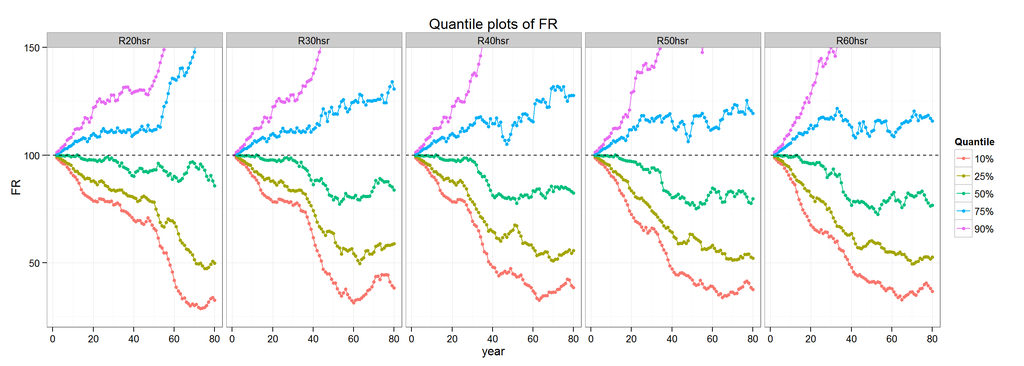

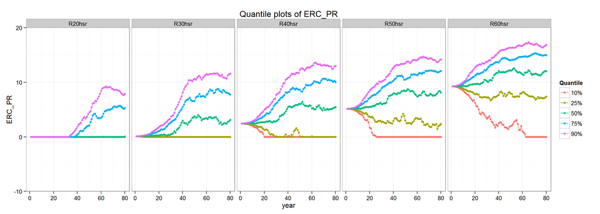

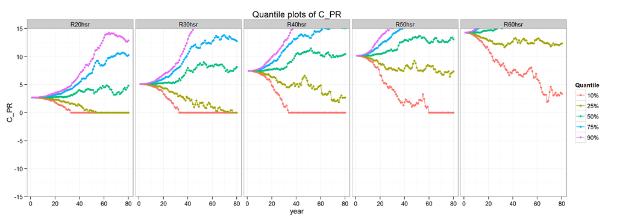

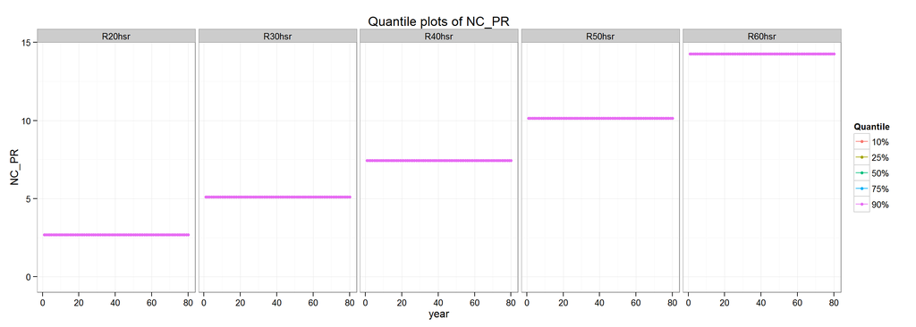

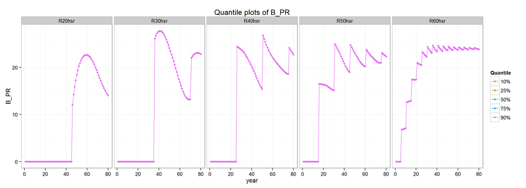

Plots for simulation 3.

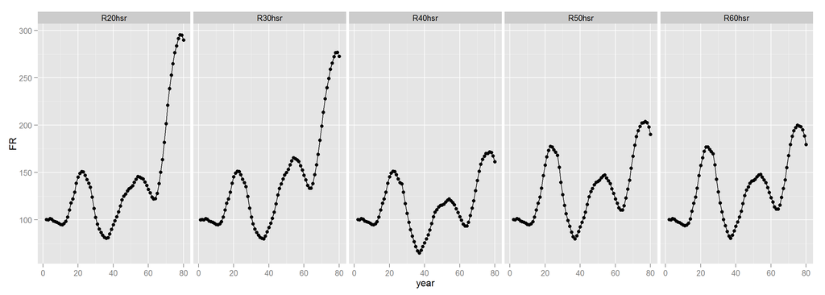

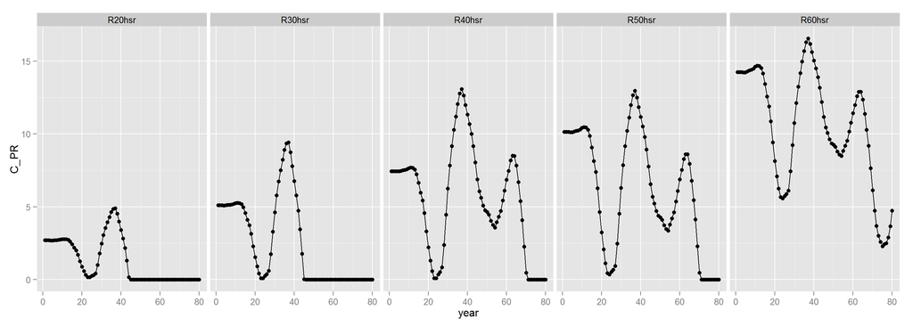

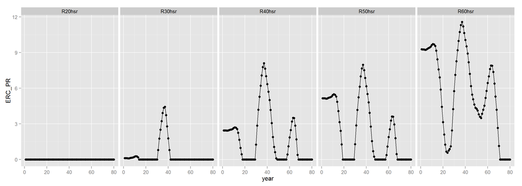

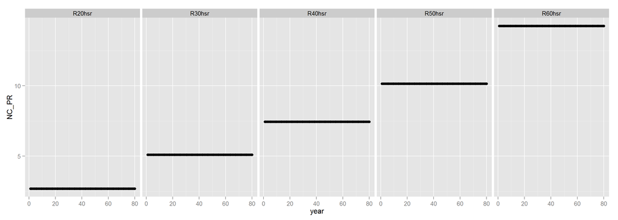

Table for Entry Age 20

| year | AL | MA | AA | FR | UAAL | NC | SC | ADC | EEC | ERC | C | ADC_PR | C_PR | ERC_PR | PR | B | i.r |
| --- | --- | --- | --- | --- | --- | --- | --- | --- | --- | --- | --- | --- | --- | --- | --- | --- | --- |
| 1 | 0.00 | 0.00 | 0.00 | NaN | 0.00 | 334.36 | 0.00 | 334.36 | 334.36 | 0.00 | 334.36 | 2.69 | 2.69 | 0.00 | 12409.00 | 0.00 | 0.13 |
| 2 | 359.44 | 376.21 | 361.11 | 100.47 | -1.68 | 354.40 | -0.09 | 354.31 | 354.31 | 0.00 | 354.31 | 2.69 | 2.69 | 0.00 | 13152.71 | 0.00 | 0.03 |
| 3 | 767.37 | 750.23 | 768.38 | 100.13 | -1.01 | 372.56 | -0.05 | 372.51 | 372.51 | 0.00 | 372.51 | 2.69 | 2.69 | 0.00 | 13826.74 | 0.00 | 0.25 |
| 4 | 1225.43 | 1408.15 | 1243.39 | 101.47 | -17.96 | 388.59 | -0.93 | 387.66 | 387.66 | 0.00 | 387.66 | 2.69 | 2.69 | 0.00 | 14421.55 | 0.00 | -0.12 |
| 5 | 1735.07 | 1584.18 | 1749.39 | 100.83 | -14.32 | 403.93 | -0.74 | 403.19 | 403.19 | 0.00 | 403.19 | 2.69 | 2.69 | 0.00 | 14990.95 | 0.00 | 0.03 |
| 6 | 2299.42 | 2037.27 | 2275.37 | 98.95 | 24.05 | 419.00 | 1.24 | 420.25 | 420.25 | 0.00 | 420.25 | 2.70 | 2.70 | 0.00 | 15550.35 | 0.00 | 0.13 |
| 7 | 2922.30 | 2766.28 | 2866.12 | 98.08 | 56.18 | 434.15 | 2.91 | 437.06 | 437.06 | 0.00 | 437.06 | 2.71 | 2.71 | 0.00 | 16112.62 | 0.00 | 0.06 |
| 8 | 3608.19 | 3385.26 | 3523.79 | 97.66 | 84.41 | 449.37 | 4.37 | 453.74 | 453.74 | 0.00 | 453.74 | 2.72 | 2.72 | 0.00 | 16677.43 | 0.00 | 0.00 |
| 9 | 4361.88 | 3847.68 | 4217.88 | 96.70 | 144.00 | 464.77 | 7.45 | 472.21 | 472.21 | 0.00 | 472.21 | 2.74 | 2.74 | 0.00 | 17248.75 | 0.00 | 0.04 |
| 10 | 5188.64 | 4485.92 | 4950.72 | 95.41 | 237.93 | 480.70 | 12.30 | 493.00 | 493.00 | 0.00 | 493.00 | 2.76 | 2.76 | 0.00 | 17840.09 | 0.00 | 0.15 |
| 11 | 6094.55 | 5728.47 | 5791.39 | 95.03 | 303.15 | 496.73 | 15.68 | 512.41 | 512.41 | 0.00 | 512.41 | 2.78 | 2.78 | 0.00 | 18434.91 | 0.00 | 0.18 |
| 12 | 7085.62 | 7379.35 | 6811.47 | 96.13 | 274.14 | 512.92 | 14.18 | 527.09 | 527.09 | 0.00 | 527.09 | 2.77 | 2.77 | 0.00 | 19035.74 | 0.00 | 0.15 |
| 13 | 8168.42 | 9125.81 | 8037.31 | 98.39 | 131.12 | 529.42 | 6.78 | 536.20 | 536.20 | 0.00 | 536.20 | 2.73 | 2.73 | 0.00 | 19648.18 | 0.00 | 0.35 |
| 14 | 9350.18 | 13022.64 | 9647.39 | 103.18 | -297.21 | 546.34 | -15.37 | 530.97 | 530.97 | 0.00 | 530.97 | 2.62 | 2.62 | 0.00 | 20276.30 | 0.00 | 0.22 |
| 15 | 10638.76 | 16478.74 | 11769.61 | 110.63 | -1130.85 | 563.80 | -58.48 | 505.31 | 505.31 | 0.00 | 505.31 | 2.41 | 2.41 | 0.00 | 20924.13 | 0.00 | 0.11 |
| 16 | 12042.75 | 18844.24 | 14192.01 | 117.85 | -2149.26 | 581.79 | -111.15 | 470.64 | 470.64 | 0.00 | 470.64 | 2.18 | 2.18 | 0.00 | 21591.89 | 0.00 | 0.00 |
| 17 | 13571.39 | 19234.29 | 16589.18 | 122.24 | -3017.79 | 600.33 | -156.07 | 444.26 | 444.26 | 0.00 | 444.26 | 1.99 | 1.99 | 0.00 | 22279.97 | 0.00 | 0.43 |
| 18 | 15234.60 | 28047.77 | 19682.41 | 129.20 | -4447.81 | 619.40 | -230.03 | 389.37 | 389.37 | 0.00 | 389.37 | 1.69 | 1.69 | 0.00 | 22987.54 | 0.00 | 0.16 |
| 19 | 17043.04 | 32881.57 | 23636.73 | 138.69 | -6593.69 | 638.94 | -341.01 | 297.93 | 297.93 | 0.00 | 297.93 | 1.26 | 1.26 | 0.00 | 23712.81 | 0.00 | -0.01 |
| 20 | 19008.13 | 32943.31 | 27598.62 | 145.19 | -8590.49 | 658.98 | -444.28 | 214.70 | 214.70 | 0.00 | 214.70 | 0.88 | 0.88 | 0.00 | 24456.62 | 0.00 | 0.10 |
| 21 | 21142.14 | 36386.91 | 31512.27 | 149.05 | -10370.12 | 679.54 | -536.32 | 143.22 | 143.22 | 0.00 | 143.22 | 0.57 | 0.57 | 0.00 | 25219.66 | 0.00 | 0.04 |
| 22 | 23458.31 | 37847.87 | 35398.10 | 150.90 | -11939.79 | 700.66 | -617.50 | 83.17 | 83.17 | 0.00 | 83.17 | 0.32 | 0.32 | 0.00 | 26003.56 | 0.00 | 0.04 |
| 23 | 25970.90 | 39525.49 | 39141.27 | 150.71 | -13170.37 | 722.35 | -681.14 | 41.21 | 41.21 | 0.00 | 41.21 | 0.15 | 0.15 | 0.00 | 26808.48 | 0.00 | -0.04 |
| 24 | 28695.24 | 38101.93 | 42258.33 | 147.27 | -13563.09 | 744.63 | -701.45 | 43.18 | 43.18 | 0.00 | 43.18 | 0.16 | 0.16 | 0.00 | 27635.23 | 0.00 | 0.09 |
| 25 | 31647.86 | 41540.83 | 45133.36 | 142.61 | -13485.50 | 767.52 | -697.44 | 70.08 | 70.08 | 0.00 | 70.08 | 0.25 | 0.25 | 0.00 | 28484.71 | 0.00 | 0.11 |
| 26 | 34846.53 | 46325.40 | 48395.96 | 138.88 | -13549.43 | 791.04 | -700.75 | 90.30 | 90.30 | 0.00 | 90.30 | 0.31 | 0.31 | 0.00 | 29357.79 | 0.00 | -0.05 |
| 27 | 38310.40 | 43895.09 | 51591.88 | 134.67 | -13281.48 | 815.23 | -686.89 | 128.34 | 128.34 | 0.00 | 128.34 | 0.42 | 0.42 | 0.00 | 30255.32 | 0.00 | -0.31 |
| 28 | 42060.04 | 30245.05 | 52249.07 | 124.22 | -10189.03 | 840.09 | -526.95 | 313.14 | 313.14 | 0.00 | 313.14 | 1.00 | 1.00 | 0.00 | 31178.16 | 0.00 | 0.04 |
| 29 | 46117.65 | 31915.43 | 51756.55 | 112.23 | -5638.90 | 865.66 | -291.63 | 574.03 | 574.03 | 0.00 | 574.03 | 1.79 | 1.79 | 0.00 | 32127.18 | 0.00 | 0.08 |
| 30 | 50507.06 | 35041.26 | 51953.73 | 102.86 | -1446.67 | 891.96 | -74.82 | 817.14 | 817.14 | 0.00 | 817.14 | 2.47 | 2.47 | 0.00 | 33103.17 | 0.00 | 0.15 |

[output cut: 75 more lines]

Table for Entry Age 30

| year | AL | MA | AA | FR | UAAL | NC | SC | ADC | EEC | ERC | C | ADC_PR | C_PR | ERC_PR | PR | B | i.r |
| --- | --- | --- | --- | --- | --- | --- | --- | --- | --- | --- | --- | --- | --- | --- | --- | --- | --- |
| 1 | 0.00 | 0.00 | 0.00 | 100.00 | 0.00 | 1624.81 | 0.00 | 1624.81 | 1591.04 | 33.77 | 1624.81 | 5.11 | 5.11 | 0.11 | 31820.81 | 0.00 | 0.13 |
| 2 | 1746.67 | 1828.18 | 1754.82 | 100.47 | -8.15 | 1677.05 | -0.42 | 1676.62 | 1642.19 | 34.43 | 1676.62 | 5.10 | 5.10 | 0.10 | 32843.83 | 0.00 | 0.03 |
| 3 | 3680.49 | 3599.34 | 3685.62 | 100.14 | -5.13 | 1729.58 | -0.27 | 1729.31 | 1693.63 | 35.68 | 1729.31 | 5.11 | 5.11 | 0.11 | 33872.66 | 0.00 | 0.25 |
| 4 | 5815.83 | 6683.29 | 5901.40 | 101.47 | -85.58 | 1783.44 | -4.43 | 1779.01 | 1746.37 | 32.64 | 1779.01 | 5.09 | 5.09 | 0.09 | 34927.43 | 0.00 | -0.12 |
| 5 | 8169.21 | 7465.02 | 8238.71 | 100.85 | -69.50 | 1839.25 | -3.59 | 1835.66 | 1801.03 | 34.63 | 1835.66 | 5.10 | 5.10 | 0.10 | 36020.50 | 0.00 | 0.03 |
| 6 | 10759.09 | 9534.22 | 10649.14 | 98.98 | 109.96 | 1897.23 | 5.69 | 1902.92 | 1857.80 | 45.12 | 1902.92 | 5.12 | 5.12 | 0.12 | 37156.08 | 0.00 | 0.13 |
| 7 | 13605.55 | 12874.11 | 13344.98 | 98.08 | 260.57 | 1957.24 | 13.48 | 1970.71 | 1916.56 | 54.15 | 1970.71 | 5.14 | 5.14 | 0.14 | 38331.19 | 0.00 | 0.06 |
| 8 | 16730.00 | 15687.89 | 16337.17 | 97.65 | 392.83 | 2018.81 | 20.32 | 2039.12 | 1976.85 | 62.27 | 2039.12 | 5.16 | 5.16 | 0.16 | 39536.99 | 0.00 | 0.00 |
| 9 | 20154.96 | 17767.10 | 19484.98 | 96.68 | 669.98 | 2081.57 | 34.65 | 2116.22 | 2038.31 | 77.91 | 2116.22 | 5.19 | 5.19 | 0.19 | 40766.19 | 0.00 | 0.04 |
| 10 | 23904.27 | 20647.51 | 22798.91 | 95.38 | 1105.36 | 2145.42 | 57.17 | 2202.59 | 2100.83 | 101.75 | 2202.59 | 5.24 | 5.24 | 0.24 | 42016.69 | 0.00 | 0.15 |
| 11 | 28003.42 | 26290.05 | 26594.34 | 94.97 | 1409.08 | 2210.46 | 72.87 | 2283.34 | 2164.52 | 118.81 | 2283.34 | 5.27 | 5.27 | 0.27 | 43290.45 | 0.00 | 0.18 |
| 12 | 32479.93 | 33785.76 | 31198.55 | 96.05 | 1281.38 | 2277.04 | 66.27 | 2343.31 | 2229.71 | 113.59 | 2343.31 | 5.25 | 5.25 | 0.25 | 44594.28 | 0.00 | 0.15 |
| 13 | 37363.74 | 41701.10 | 36732.47 | 98.31 | 631.27 | 2345.55 | 32.65 | 2378.20 | 2296.80 | 81.40 | 2378.20 | 5.18 | 5.18 | 0.18 | 45936.07 | 0.00 | 0.35 |
| 14 | 42687.48 | 59410.87 | 44004.61 | 103.09 | -1317.13 | 2416.07 | -68.12 | 2347.95 | 2347.95 | 0.00 | 2347.95 | 4.96 | 4.96 | 0.00 | 47317.14 | 0.00 | 0.22 |
| 15 | 48486.32 | 75087.59 | 53605.35 | 110.56 | -5119.03 | 2488.66 | -264.74 | 2223.92 | 2223.92 | 0.00 | 2223.92 | 4.56 | 4.56 | 0.00 | 48738.84 | 0.00 | 0.11 |
| 16 | 54798.11 | 85779.07 | 64561.83 | 117.82 | -9763.72 | 2563.40 | -504.96 | 2058.44 | 2058.44 | 0.00 | 2058.44 | 4.10 | 4.10 | 0.00 | 50202.47 | 0.00 | 0.00 |
| 17 | 61663.62 | 87471.01 | 75388.93 | 122.26 | -13725.32 | 2640.34 | -709.84 | 1930.50 | 1930.50 | 0.00 | 1930.50 | 3.73 | 3.73 | 0.00 | 51709.39 | 0.00 | 0.43 |
| 18 | 69126.76 | 127423.69 | 89364.14 | 129.28 | -20237.38 | 2719.57 | -1046.63 | 1672.94 | 1672.94 | 0.00 | 1672.94 | 3.14 | 3.14 | 0.00 | 53260.98 | 0.00 | 0.16 |
| 19 | 77234.80 | 149273.13 | 107237.28 | 138.85 | -30002.47 | 2801.15 | -1551.66 | 1249.49 | 1249.49 | 0.00 | 1249.49 | 2.28 | 2.28 | 0.00 | 54858.72 | 0.00 | -0.01 |
| 20 | 86038.65 | 149451.14 | 125130.56 | 145.44 | -39091.90 | 2885.17 | -2021.74 | 863.42 | 863.42 | 0.00 | 863.42 | 1.53 | 1.53 | 0.00 | 56504.07 | 0.00 | 0.10 |
| 21 | 95593.10 | 164952.05 | 142785.93 | 149.37 | -47192.83 | 2971.69 | -2440.70 | 530.98 | 530.98 | 0.00 | 530.98 | 0.91 | 0.91 | 0.00 | 58198.56 | 0.00 | 0.04 |
| 22 | 105957.15 | 171452.47 | 160295.39 | 151.28 | -54338.24 | 3060.78 | -2810.25 | 250.54 | 250.54 | 0.00 | 250.54 | 0.42 | 0.42 | 0.00 | 59943.44 | 0.00 | 0.04 |
| 23 | 117194.28 | 178920.62 | 177138.65 | 151.15 | -59944.37 | 3152.55 | -3100.18 | 52.36 | 52.36 | 0.00 | 52.36 | 0.08 | 0.08 | 0.00 | 61740.59 | 0.00 | -0.04 |
| 24 | 129372.84 | 172347.34 | 191121.56 | 147.73 | -61748.72 | 3247.06 | -3193.50 | 53.56 | 53.56 | 0.00 | 53.56 | 0.08 | 0.08 | 0.00 | 63591.53 | 0.00 | 0.09 |
| 25 | 142566.39 | 187748.27 | 203984.81 | 143.08 | -61418.41 | 3344.40 | -3176.42 | 167.98 | 167.98 | 0.00 | 167.98 | 0.26 | 0.26 | 0.00 | 65497.88 | 0.00 | 0.11 |
| 26 | 156854.10 | 209207.02 | 218578.91 | 139.35 | -61724.81 | 3444.66 | -3192.26 | 252.39 | 252.39 | 0.00 | 252.39 | 0.37 | 0.37 | 0.00 | 67461.34 | 0.00 | -0.05 |
| 27 | 172321.17 | 198084.71 | 232860.18 | 135.13 | -60539.01 | 3547.92 | -3130.94 | 416.98 | 416.98 | 0.00 | 416.98 | 0.60 | 0.60 | 0.00 | 69483.63 | 0.00 | -0.31 |
| 28 | 189059.27 | 136374.97 | 235651.07 | 124.64 | -46591.80 | 3654.27 | -2409.62 | 1244.65 | 1244.65 | 0.00 | 1244.65 | 1.74 | 1.74 | 0.00 | 71566.51 | 0.00 | 0.04 |
| 29 | 207167.05 | 143732.01 | 233233.14 | 112.58 | -26066.08 | 3763.81 | -1348.08 | 2415.73 | 2415.73 | 0.00 | 2415.73 | 3.28 | 3.28 | 0.00 | 73711.71 | 0.00 | 0.08 |
| 30 | 226750.68 | 157626.49 | 233913.73 | 103.16 | -7163.05 | 3876.62 | -370.46 | 3506.16 | 3506.16 | 0.00 | 3506.16 | 4.62 | 4.62 | 0.00 | 75921.00 | 0.00 | 0.15 |

[output cut: 75 more lines]

Table for Entry Age 40

| year | AL | MA | AA | FR | UAAL | NC | SC | ADC | EEC | ERC | C | ADC_PR | C_PR | ERC_PR | PR | B | i.r |
| --- | --- | --- | --- | --- | --- | --- | --- | --- | --- | --- | --- | --- | --- | --- | --- | --- | --- |
| 1 | 0.00 | 0.00 | 0.00 | NaN | 0.00 | 2265.46 | 0.00 | 2265.46 | 1520.60 | 744.85 | 2265.46 | 7.45 | 7.45 | 2.45 | 30412.02 | 0.00 | 0.13 |
| 2 | 2435.36 | 2549.02 | 2446.73 | 100.47 | -11.37 | 2333.42 | -0.59 | 2332.83 | 1566.22 | 766.61 | 2332.83 | 7.45 | 7.45 | 2.45 | 31324.38 | 0.00 | 0.03 |
| 3 | 5126.44 | 5013.52 | 5133.62 | 100.14 | -7.18 | 2403.42 | -0.37 | 2403.05 | 1613.21 | 789.84 | 2403.05 | 7.45 | 7.45 | 2.45 | 32264.11 | 0.00 | 0.25 |
| 4 | 8094.60 | 9302.00 | 8213.75 | 101.47 | -119.14 | 2475.52 | -6.16 | 2469.36 | 1661.60 | 807.76 | 2469.36 | 7.43 | 7.43 | 2.43 | 33232.04 | 0.00 | -0.12 |
| 5 | 11362.89 | 10384.11 | 11459.79 | 100.85 | -96.90 | 2549.79 | -5.01 | 2544.78 | 1711.45 | 833.33 | 2544.78 | 7.43 | 7.43 | 2.43 | 34229.00 | 0.00 | 0.03 |
| 6 | 14956.13 | 13253.53 | 14803.56 | 98.98 | 152.57 | 2626.28 | 7.89 | 2634.17 | 1762.79 | 871.38 | 2634.17 | 7.47 | 7.47 | 2.47 | 35255.87 | 0.00 | 0.13 |
| 7 | 18901.09 | 17883.85 | 18539.09 | 98.08 | 362.00 | 2705.07 | 18.72 | 2723.79 | 1815.68 | 908.12 | 2723.79 | 7.50 | 7.50 | 2.50 | 36313.54 | 0.00 | 0.06 |
| 8 | 23226.63 | 21777.99 | 22680.72 | 97.65 | 545.91 | 2786.22 | 28.23 | 2814.46 | 1870.15 | 944.31 | 2814.46 | 7.52 | 7.52 | 2.52 | 37402.95 | 0.00 | 0.00 |
| 9 | 27963.81 | 24648.07 | 27032.99 | 96.67 | 930.83 | 2869.81 | 48.14 | 2917.95 | 1926.25 | 991.70 | 2917.95 | 7.57 | 7.57 | 2.57 | 38525.04 | 0.00 | 0.04 |
| 10 | 33146.15 | 28625.48 | 31610.97 | 95.37 | 1535.18 | 2955.91 | 79.40 | 3035.30 | 1984.04 | 1051.26 | 3035.30 | 7.65 | 7.65 | 2.65 | 39680.79 | 0.00 | 0.15 |
| 11 | 38809.71 | 36427.13 | 36852.58 | 94.96 | 1957.12 | 3044.58 | 101.22 | 3145.80 | 2043.56 | 1102.24 | 3145.80 | 7.70 | 7.70 | 2.70 | 40871.21 | 0.00 | 0.18 |
| 12 | 44993.36 | 46791.85 | 43211.84 | 96.04 | 1781.52 | 3135.92 | 92.14 | 3228.06 | 2104.87 | 1123.19 | 3228.06 | 7.67 | 7.67 | 2.67 | 42097.35 | 0.00 | 0.15 |
| 13 | 51738.97 | 57734.25 | 50856.61 | 98.29 | 882.36 | 3230.00 | 45.63 | 3275.63 | 2168.01 | 1107.62 | 3275.63 | 7.55 | 7.55 | 2.55 | 43360.27 | 0.00 | 0.35 |
| 14 | 59091.65 | 82230.22 | 60904.74 | 103.07 | -1813.10 | 3326.90 | -93.77 | 3233.13 | 2233.05 | 1000.07 | 3233.13 | 7.24 | 7.24 | 2.24 | 44661.08 | 0.00 | 0.22 |
| 15 | 67099.93 | 103908.03 | 74174.88 | 110.54 | -7074.95 | 3426.70 | -365.90 | 3060.80 | 2300.05 | 760.76 | 3060.80 | 6.65 | 6.65 | 1.65 | 46000.91 | 0.00 | 0.11 |
| 16 | 75816.14 | 118684.61 | 89319.43 | 117.81 | -13503.29 | 3529.51 | -698.36 | 2831.15 | 2369.05 | 462.10 | 2831.15 | 5.98 | 5.98 | 0.98 | 47380.94 | 0.00 | 0.00 |
| 17 | 85296.56 | 121008.74 | 104282.81 | 122.26 | -18986.24 | 3635.39 | -981.92 | 2653.47 | 2440.12 | 213.35 | 2653.47 | 5.44 | 5.44 | 0.44 | 48802.37 | 0.00 | 0.43 |
| 18 | 95601.85 | 176255.35 | 123598.86 | 129.29 | -27997.01 | 3744.45 | -1447.94 | 2296.51 | 2296.51 | 0.00 | 2296.51 | 4.57 | 4.57 | 0.00 | 50266.44 | 0.00 | 0.16 |
| 19 | 106797.28 | 206457.71 | 148305.01 | 138.87 | -41507.73 | 3856.79 | -2146.68 | 1710.10 | 1710.10 | 0.00 | 1710.10 | 3.30 | 3.30 | 0.00 | 51774.43 | 0.00 | -0.01 |
| 20 | 118953.12 | 206685.98 | 173037.30 | 145.47 | -54084.18 | 3972.49 | -2797.11 | 1175.38 | 1175.38 | 0.00 | 1175.38 | 2.20 | 2.20 | 0.00 | 53327.66 | 0.00 | 0.10 |
| 21 | 132145.03 | 228102.70 | 197437.88 | 149.41 | -65292.86 | 4091.66 | -3376.80 | 714.87 | 714.87 | 0.00 | 714.87 | 1.30 | 1.30 | 0.00 | 54927.49 | 0.00 | 0.04 |
| 22 | 146454.44 | 237071.66 | 221633.85 | 151.33 | -75179.41 | 4214.41 | -3888.11 | 326.31 | 326.31 | 0.00 | 326.31 | 0.58 | 0.58 | 0.00 | 56575.32 | 0.00 | 0.04 |
| 23 | 161969.02 | 247377.11 | 244905.93 | 151.21 | -82936.91 | 4340.85 | -4289.31 | 51.54 | 51.54 | 0.00 | 51.54 | 0.09 | 0.09 | 0.00 | 58272.58 | 0.00 | -0.04 |
| 24 | 178783.11 | 238268.74 | 264219.38 | 147.79 | -85436.28 | 4471.07 | -4418.57 | 52.50 | 52.50 | 0.00 | 52.50 | 0.09 | 0.09 | 0.00 | 60020.76 | 0.00 | 0.09 |
| 25 | 196998.24 | 259536.95 | 281981.41 | 143.14 | -84983.17 | 4605.20 | -4395.13 | 210.07 | 210.07 | 0.00 | 210.07 | 0.34 | 0.34 | 0.00 | 61821.38 | 0.00 | 0.11 |
| 26 | 216723.70 | 289176.16 | 302133.44 | 139.41 | -85409.73 | 4743.36 | -4417.19 | 326.17 | 326.17 | 0.00 | 326.17 | 0.51 | 0.51 | 0.00 | 63676.02 | 15535.51 | -0.05 |
| 27 | 221376.42 | 259089.03 | 305352.08 | 137.93 | -83975.65 | 4885.66 | -4343.03 | 542.63 | 542.63 | 0.00 | 542.63 | 0.83 | 0.83 | 0.00 | 65586.30 | 15901.68 | -0.31 |
| 28 | 226137.44 | 167447.80 | 292365.21 | 129.29 | -66227.77 | 5032.23 | -3425.15 | 1607.08 | 1607.08 | 0.00 | 1607.08 | 2.38 | 2.38 | 0.00 | 67553.89 | 16269.07 | 0.04 |
| 29 | 231018.15 | 159571.81 | 271335.85 | 117.45 | -40317.70 | 5183.20 | -2085.14 | 3098.06 | 3098.06 | 0.00 | 3098.06 | 4.45 | 4.45 | 0.00 | 69580.51 | 16638.96 | 0.08 |
| 30 | 236029.56 | 157500.48 | 252682.12 | 107.06 | -16652.56 | 5338.69 | -861.23 | 4477.46 | 3583.40 | 894.07 | 4477.46 | 6.25 | 6.25 | 1.25 | 71667.92 | 17010.94 | 0.15 |

[output cut: 75 more lines]

Table for Entry Age 50

| year | AL | MA | AA | FR | UAAL | NC | SC | ADC | EEC | ERC | C | ADC_PR | C_PR | ERC_PR | PR | B | i.r |
| --- | --- | --- | --- | --- | --- | --- | --- | --- | --- | --- | --- | --- | --- | --- | --- | --- | --- |
| 1 | 0.00 | 0.00 | 0.00 | NaN | 0.00 | 3116.00 | 0.00 | 3116.00 | 1535.07 | 1580.94 | 3116.00 | 10.15 | 10.15 | 5.15 | 30701.33 | 0.00 | 0.13 |
| 2 | 3349.70 | 3506.02 | 3365.34 | 100.47 | -15.63 | 3209.48 | -0.81 | 3208.67 | 1581.12 | 1627.56 | 3208.67 | 10.15 | 10.15 | 5.15 | 31622.37 | 0.00 | 0.03 |
| 3 | 7051.13 | 6895.81 | 7061.00 | 100.14 | -9.87 | 3305.77 | -0.51 | 3305.26 | 1628.55 | 1676.71 | 3305.26 | 10.15 | 10.15 | 5.15 | 32571.04 | 0.00 | 0.25 |
| 4 | 11133.66 | 12794.37 | 11297.54 | 101.47 | -163.88 | 3404.94 | -8.48 | 3396.47 | 1677.41 | 1719.06 | 3396.47 | 10.12 | 10.12 | 5.12 | 33548.17 | 0.00 | -0.12 |
| 5 | 15629.00 | 14282.75 | 15762.28 | 100.85 | -133.28 | 3507.09 | -6.89 | 3500.20 | 1727.73 | 1772.47 | 3500.20 | 10.13 | 10.13 | 5.13 | 34554.61 | 0.00 | 0.03 |
| 6 | 20571.29 | 18229.47 | 20361.44 | 98.98 | 209.85 | 3612.30 | 10.85 | 3623.15 | 1779.56 | 1843.59 | 3623.15 | 10.18 | 10.18 | 5.18 | 35591.25 | 0.00 | 0.13 |
| 7 | 25997.36 | 24598.21 | 25499.46 | 98.08 | 497.91 | 3720.67 | 25.75 | 3746.42 | 1832.95 | 1913.47 | 3746.42 | 10.22 | 10.22 | 5.22 | 36658.99 | 0.00 | 0.06 |
| 8 | 31946.89 | 29954.37 | 31196.02 | 97.65 | 750.86 | 3832.29 | 38.83 | 3871.12 | 1887.94 | 1983.19 | 3871.12 | 10.25 | 10.25 | 5.25 | 37758.76 | 0.00 | 0.00 |
| 9 | 38462.62 | 33902.00 | 37182.32 | 96.67 | 1280.30 | 3947.26 | 66.21 | 4013.47 | 1944.58 | 2068.90 | 4013.47 | 10.32 | 10.32 | 5.32 | 38891.52 | 0.00 | 0.04 |
| 10 | 45590.62 | 39372.70 | 43479.07 | 95.37 | 2111.55 | 4065.68 | 109.20 | 4174.88 | 2002.91 | 2171.97 | 4174.88 | 10.42 | 10.42 | 5.42 | 40058.27 | 0.00 | 0.15 |
| 11 | 53380.52 | 50103.43 | 50688.61 | 94.96 | 2691.91 | 4187.65 | 139.22 | 4326.87 | 2063.00 | 2263.87 | 4326.87 | 10.49 | 10.49 | 5.49 | 41260.01 | 0.00 | 0.18 |
| 12 | 61885.78 | 64359.50 | 59435.40 | 96.04 | 2450.37 | 4313.28 | 126.73 | 4440.01 | 2124.89 | 2315.11 | 4440.01 | 10.45 | 10.45 | 5.45 | 42497.82 | 0.00 | 0.15 |
| 13 | 71163.98 | 79410.15 | 69950.34 | 98.29 | 1213.64 | 4442.68 | 62.77 | 4505.44 | 2188.64 | 2316.80 | 4505.44 | 10.29 | 10.29 | 5.29 | 43772.75 | 0.00 | 0.35 |
| 14 | 81277.16 | 113102.94 | 83770.97 | 103.07 | -2493.81 | 4575.96 | -128.97 | 4446.98 | 2254.30 | 2192.69 | 4446.98 | 9.86 | 9.86 | 4.86 | 45085.93 | 0.00 | 0.22 |
| 15 | 92292.10 | 142919.51 | 102023.29 | 110.54 | -9731.19 | 4713.23 | -503.27 | 4209.96 | 2321.93 | 1888.03 | 4209.96 | 9.07 | 9.07 | 4.07 | 46438.51 | 0.00 | 0.11 |
| 16 | 104280.73 | 163243.85 | 122853.74 | 117.81 | -18573.00 | 4854.63 | -960.55 | 3894.08 | 2391.58 | 1502.50 | 3894.08 | 8.14 | 8.14 | 3.14 | 47831.67 | 7896.96 | 0.00 |
| 17 | 108831.29 | 158576.55 | 135008.29 | 124.05 | -26177.01 | 5000.27 | -1353.81 | 3646.46 | 2463.33 | 1183.13 | 3646.46 | 7.40 | 7.40 | 2.40 | 49266.62 | 8114.36 | 0.43 |
| 18 | 113645.99 | 219650.58 | 151762.89 | 133.54 | -38116.90 | 5150.28 | -1971.32 | 3178.96 | 2537.23 | 641.73 | 3178.96 | 6.26 | 6.26 | 1.26 | 50744.61 | 8335.54 | 0.16 |
| 19 | 118745.28 | 248017.23 | 174347.37 | 146.82 | -55602.09 | 5304.79 | -2875.61 | 2429.18 | 2429.18 | 0.00 | 2429.18 | 4.65 | 4.65 | 0.00 | 52266.95 | 8561.37 | -0.01 |
| 20 | 124150.35 | 240163.19 | 196162.88 | 158.00 | -72012.54 | 5463.93 | -3724.32 | 1739.61 | 1739.61 | 0.00 | 1739.61 | 3.23 | 3.23 | 0.00 | 53834.96 | 8791.84 | 0.10 |
| 21 | 129884.12 | 255811.08 | 216593.01 | 166.76 | -86708.89 | 5627.85 | -4484.38 | 1143.46 | 1143.46 | 0.00 | 1143.46 | 2.06 | 2.06 | 0.00 | 55450.01 | 9026.80 | 0.04 |
| 22 | 135971.56 | 256871.19 | 235753.48 | 173.38 | -99781.93 | 5796.68 | -5160.49 | 636.19 | 636.19 | 0.00 | 636.19 | 1.11 | 1.11 | 0.00 | 57113.51 | 9266.01 | 0.04 |
| 23 | 142439.90 | 258676.32 | 252827.62 | 177.50 | -110387.72 | 5970.58 | -5709.00 | 261.59 | 261.59 | 0.00 | 261.59 | 0.44 | 0.44 | 0.00 | 58826.91 | 9463.31 | -0.04 |
| 24 | 149368.21 | 240238.95 | 264338.34 | 176.97 | -114970.13 | 6149.70 | -5945.99 | 203.71 | 203.71 | 0.00 | 203.71 | 0.34 | 0.34 | 0.00 | 60591.72 | 9657.79 | 0.09 |
| 25 | 156799.63 | 251329.68 | 272863.24 | 174.02 | -116063.61 | 6334.19 | -6002.54 | 331.65 | 331.65 | 0.00 | 331.65 | 0.53 | 0.53 | 0.00 | 62409.47 | 9850.04 | 0.11 |
| 26 | 164780.07 | 269208.32 | 282568.96 | 171.48 | -117788.89 | 6524.22 | -6091.77 | 432.45 | 432.45 | 0.00 | 432.45 | 0.67 | 0.67 | 0.00 | 64281.76 | 10042.71 | -0.05 |
| 27 | 173356.20 | 245500.57 | 291420.84 | 168.11 | -118064.64 | 6719.95 | -6106.03 | 613.91 | 613.91 | 0.00 | 613.91 | 0.93 | 0.93 | 0.00 | 66210.21 | 10240.28 | -0.31 |
| 28 | 182573.55 | 162050.71 | 283927.53 | 155.51 | -101353.98 | 6921.54 | -5241.79 | 1679.75 | 1679.75 | 0.00 | 1679.75 | 2.46 | 2.46 | 0.00 | 68196.52 | 10448.74 | 0.04 |
| 29 | 192474.83 | 160089.73 | 268884.73 | 139.70 | -76409.90 | 7129.19 | -3951.74 | 3177.45 | 3177.45 | 0.00 | 3177.45 | 4.52 | 4.52 | 0.00 | 70242.41 | 10675.39 | 0.08 |
| 30 | 203098.28 | 164576.68 | 257101.62 | 126.59 | -54003.33 | 7343.07 | -2792.93 | 4550.14 | 3617.48 | 932.65 | 4550.14 | 6.29 | 6.29 | 1.29 | 72349.69 | 10928.40 | 0.15 |

[output cut: 75 more lines]

Table for Entry Age 60

| year | AL | MA | AA | FR | UAAL | NC | SC | ADC | EEC | ERC | C | ADC_PR | C_PR | ERC_PR | PR | B | i.r |
| --- | --- | --- | --- | --- | --- | --- | --- | --- | --- | --- | --- | --- | --- | --- | --- | --- | --- |
| 1 | 0.00 | 0.00 | 0.00 | NaN | 0.00 | 4560.67 | 0.00 | 4560.67 | 1598.21 | 2962.45 | 4560.67 | 14.27 | 14.27 | 9.27 | 31964.27 | 0.00 | 0.13 |
| 2 | 4902.72 | 5131.51 | 4925.60 | 100.47 | -22.88 | 4697.49 | -1.18 | 4696.30 | 1646.16 | 3050.14 | 4696.30 | 14.26 | 14.26 | 9.26 | 32923.19 | 0.00 | 0.03 |
| 3 | 10320.22 | 10092.89 | 10334.67 | 100.14 | -14.45 | 4838.41 | -0.75 | 4837.67 | 1695.54 | 3142.12 | 4837.67 | 14.27 | 14.27 | 9.27 | 33910.89 | 0.00 | 0.25 |
| 4 | 16295.53 | 18726.19 | 16535.38 | 101.47 | -239.85 | 4983.56 | -12.40 | 4971.16 | 1746.41 | 3224.75 | 4971.16 | 14.23 | 14.23 | 9.23 | 34928.22 | 0.00 | -0.12 |
| 5 | 22875.03 | 20904.62 | 23070.11 | 100.85 | -195.08 | 5133.07 | -10.09 | 5122.98 | 1798.80 | 3324.18 | 5122.98 | 14.24 | 14.24 | 9.24 | 35976.06 | 0.00 | 0.03 |
| 6 | 30108.71 | 26681.15 | 29801.57 | 98.98 | 307.14 | 5287.06 | 15.88 | 5302.95 | 1852.77 | 3450.18 | 5302.95 | 14.31 | 14.31 | 9.31 | 37055.34 | 2512.56 | 0.13 |
| 7 | 35349.45 | 33174.38 | 34607.98 | 97.90 | 741.48 | 5445.68 | 38.35 | 5484.02 | 1908.35 | 3575.67 | 5484.02 | 14.37 | 14.37 | 9.37 | 38167.00 | 2606.80 | 0.06 |
| 8 | 41052.45 | 38099.02 | 39929.07 | 97.26 | 1123.37 | 5609.05 | 58.10 | 5667.14 | 1965.60 | 3701.54 | 5667.14 | 14.42 | 14.42 | 9.42 | 39312.02 | 2710.05 | 0.00 |
| 9 | 47247.80 | 41148.98 | 45406.75 | 96.10 | 1841.05 | 5777.32 | 95.21 | 5872.53 | 2024.57 | 3847.96 | 5872.53 | 14.50 | 14.50 | 9.50 | 40491.38 | 2825.00 | 0.04 |
| 10 | 53965.12 | 45895.14 | 51048.78 | 94.60 | 2916.34 | 5950.64 | 150.83 | 6101.46 | 2085.31 | 4016.16 | 6101.46 | 14.63 | 14.63 | 9.63 | 41706.12 | 2954.77 | 0.15 |
| 11 | 61233.06 | 56424.80 | 57523.86 | 93.94 | 3709.20 | 6129.16 | 191.83 | 6320.99 | 2147.87 | 4173.12 | 6320.99 | 14.71 | 14.71 | 9.71 | 42957.30 | 5430.10 | 0.18 |
| 12 | 66577.02 | 67771.24 | 62956.48 | 94.56 | 3620.55 | 6313.03 | 187.25 | 6500.28 | 2212.30 | 4287.98 | 6500.28 | 14.69 | 14.69 | 9.69 | 44246.02 | 5619.11 | 0.15 |
| 13 | 72316.26 | 79240.36 | 69820.73 | 96.55 | 2495.53 | 6502.42 | 129.06 | 6631.48 | 2278.67 | 4352.81 | 6631.48 | 14.55 | 14.55 | 9.55 | 45573.40 | 5809.91 | 0.35 |
| 14 | 78484.43 | 107908.92 | 79397.76 | 101.16 | -913.33 | 6697.49 | -47.24 | 6650.26 | 2347.03 | 4303.23 | 6650.26 | 14.17 | 14.17 | 9.17 | 46940.60 | 6019.07 | 0.22 |
| 15 | 85100.07 | 131965.20 | 92905.73 | 109.17 | -7805.66 | 6898.42 | -403.69 | 6494.73 | 2417.44 | 4077.29 | 6494.73 | 13.43 | 13.43 | 8.43 | 48348.82 | 6251.64 | 0.11 |
| 16 | 92177.86 | 146688.42 | 108387.01 | 117.58 | -16209.15 | 7105.37 | -838.30 | 6267.07 | 2489.96 | 3777.11 | 6267.07 | 12.58 | 12.58 | 7.58 | 49799.28 | 8668.96 | 0.00 |
| 17 | 97410.34 | 143684.51 | 120837.59 | 124.05 | -23427.25 | 7318.53 | -1211.60 | 6106.93 | 2564.66 | 3542.27 | 6106.93 | 11.91 | 11.91 | 6.91 | 51293.26 | 8920.05 | 0.43 |
| 18 | 102994.48 | 200783.54 | 137621.12 | 133.62 | -34626.64 | 7538.09 | -1790.81 | 5747.28 | 2641.60 | 3105.68 | 5747.28 | 10.88 | 10.88 | 5.88 | 52832.06 | 9175.52 | 0.16 |
| 19 | 108958.83 | 228199.92 | 159928.76 | 146.78 | -50969.93 | 7764.23 | -2636.05 | 5128.18 | 2720.85 | 2407.33 | 5128.18 | 9.42 | 9.42 | 4.42 | 54417.02 | 9452.80 | -0.01 |
| 20 | 115315.53 | 222281.67 | 181652.21 | 157.53 | -66336.68 | 7997.16 | -3430.78 | 4566.38 | 2802.48 | 1763.90 | 4566.38 | 8.15 | 8.15 | 3.15 | 56049.53 | 9758.39 | 0.10 |
| 21 | 122070.87 | 238229.64 | 202114.67 | 165.57 | -80043.81 | 8237.07 | -4139.68 | 4097.39 | 2886.55 | 1210.84 | 4097.39 | 7.10 | 7.10 | 2.10 | 57731.02 | 12096.22 | 0.04 |
| 22 | 127077.60 | 238535.88 | 219244.00 | 172.53 | -92166.40 | 8484.18 | -4766.63 | 3717.55 | 2973.15 | 744.40 | 3717.55 | 6.25 | 6.25 | 1.25 | 59462.95 | 12379.43 | 0.04 |
| 23 | 132421.02 | 239536.86 | 234381.84 | 177.00 | -101960.82 | 8738.71 | -5273.18 | 3465.53 | 3062.34 | 403.19 | 3465.53 | 5.66 | 5.66 | 0.66 | 61246.84 | 12666.86 | -0.04 |
| 24 | 138129.84 | 221808.42 | 244250.39 | 176.83 | -106120.55 | 9000.87 | -5488.31 | 3512.56 | 3154.21 | 358.35 | 3512.56 | 5.57 | 5.57 | 0.57 | 63084.24 | 12976.66 | 0.09 |
| 25 | 144215.61 | 231247.52 | 251276.11 | 174.24 | -107060.51 | 9270.90 | -5536.92 | 3733.98 | 3248.84 | 485.14 | 3733.98 | 5.75 | 5.75 | 0.75 | 64976.77 | 13316.85 | 0.11 |
| 26 | 150682.38 | 246779.08 | 259274.58 | 172.07 | -108592.21 | 9549.02 | -5616.14 | 3932.89 | 3346.30 | 586.58 | 3932.89 | 5.88 | 5.88 | 0.88 | 66926.07 | 15545.74 | -0.05 |
| 27 | 155537.08 | 222395.51 | 264357.23 | 169.96 | -108820.14 | 9835.50 | -5627.93 | 4207.57 | 3446.69 | 760.88 | 4207.57 | 6.10 | 6.10 | 1.10 | 68933.86 | 15825.69 | -0.31 |
| 28 | 160762.91 | 144808.65 | 254493.06 | 158.30 | -93730.15 | 10130.56 | -4847.51 | 5283.05 | 3550.09 | 1732.96 | 5283.05 | 7.44 | 7.44 | 2.44 | 71001.87 | 16110.71 | 0.04 |
| 29 | 166391.47 | 139931.77 | 237645.55 | 142.82 | -71254.08 | 10434.48 | -3685.10 | 6749.38 | 3656.60 | 3092.78 | 6749.38 | 9.23 | 9.23 | 4.23 | 73131.93 | 16420.73 | 0.08 |
| 30 | 172435.61 | 140491.35 | 223559.87 | 129.65 | -51124.26 | 10747.51 | -2644.03 | 8103.48 | 3766.29 | 4337.19 | 8103.48 | 10.76 | 10.76 | 5.76 | 75325.89 | 16766.45 | 0.15 |

[output cut: 75 more lines]